# Measuring Network Risk in the Semiconductor Supply Chain

Dirk Laschat

2021-10-27

# Caclulation of conectedness measures

First, load the saved workspace

```r
# loading the workspace
load("C:\\Users\\Dirk\\OneDrive - Universität Münster\\6. Promotion\\COVID - Disruption of Value Chains\\Conntectedness VAR - Consumer Electronics-ohne EMS.R.RData")
```

Total connectedness for the whole system

```r
ovr=vector("list",(nrow(Vol_data)-w)/5)
for (i in 1:((nrow(Vol_data)-w)/5)){

  ovr[[i]]=sum(rowSums(Con_Matrices[[i]])/rowSums(Con_Matrices[[i]]!=0))/sum(rowSums(Con_Matrices[[i]]!=0)!=0)}
```

Total conectedness - Across countries

```r
ovr_cc=vector("list",(nrow(Vol_data)-w)/5)
for (i in 1:((nrow(Vol_data)-w)/5)){

  ovr_cc[[i]]=sum(sum(rowSums(Con_Matrices[[i]][!grepl("Europe",plot_info[match(colnames(Con_Matrices[[i]]),names),4]),grep("Europe",plot_info[match(colnames(Con_Matrices[[i]]),names),4])])/
                      rowSums(Con_Matrices[[i]][!grepl("Europe",plot_info[match(colnames(Con_Matrices[[i]]),names),4]),grep("Europe",plot_info[match(colnames(Con_Matrices[[i]]),names),4])]!=0))/
                  sum(rowSums(Con_Matrices[[i]][!grepl("Europe",plot_info[match(colnames(Con_Matrices[[i]]),names),4]),grep("Europe",plot_info[match(colnames(Con_Matrices[[i]]),names),4])]!=0)!=0),

                  sum(rowSums(Con_Matrices[[i]][!grepl("North America",plot_info[match(colnames(Con_Matrices[[i]]),names),4]),grep("North America",plot_info[match(colnames(Con_Matrices[[i]]),names),4])])/
                      rowSums(Con_Matrices[[i]][!grepl("North America",plot_info[match(colnames(Con_Matrices[[i]]),names),4]),grep("North America",plot_info[match(colnames(Con_Matrices[[i]]),names),4])]!=0))/
                  sum(rowSums(Con_Matrices[[i]][!grepl("North America",plot_info[match(colnames(Con_Matrices[[i]]),names),4]),grep("North America",plot_info[match(colnames(Con_Matrices[[i]]),names),4])]!=0)!=0),

                  sum(rowSums(Con_Matrices[[i]][!grepl("Asia",plot_info[match(colnames(Con_Matrices[[i]]),names),4]),grep("Asia",plot_info[match(colnames(Con_Matrices[[i]]),names),4])])/
                      rowSums(Con_Matrices[[i]][!grepl("Asia",plot_info[match(colnames(Con_Matrices[[i]]),names),4]),grep("Asia",plot_info[match(colnames(Con_Matrices[[i]]),names),4])]!=0))/
                  sum(rowSums(Con_Matrices[[i]][!grepl("Asia",plot_info[match(colnames(Con_Matrices[[i]]),names),4]),grep("Asia",plot_info[match(colnames(Con_Matrices[[i]]),names),4])]!=0)!=0)
            )}
```

Total conectedness - within a country (IN=OUT)

```r
ovr_wc=vector("list",(nrow(Vol_data)-w)/5)
for (i in 1:((nrow(Vol_data)-w)/5)){

  ovr_wc[[i]]= sum(sum(rowSums(Con_Matrices[[i]][grep("Europe",plot_info[match(colnames(Con_Matrices[[i]]),names),4]),grep("Europe",plot_info[match(colnames(Con_Matrices[[i]]),names),4])])
                       /rowSums(Con_Matrices[[i]][grep("Europe",plot_info[match(colnames(Con_Matrices[[i]]),names),4]),grep("Europe",plot_info[match(colnames(Con_Matrices[[i]]),names),4])]!=0))
                   /sum(rowSums(Con_Matrices[[i]][grep("Europe",plot_info[match(colnames(Con_Matrices[[i]]),names),4]),grep("Europe",plot_info[match(colnames(Con_Matrices[[i]]),names),4])]!=0)!=0),


                   sum(rowSums(Con_Matrices[[i]][grep("North America",plot_info[match(colnames(Con_Matrices[[i]]),names),4]),grep("North America",plot_info[match(colnames(Con_Matrices[[i]]),names),4])])
                       /rowSums(Con_Matrices[[i]][grep("North America",plot_info[match(colnames(Con_Matrices[[i]]),names),4]),grep("North America",plot_info[match(colnames(Con_Matrices[[i]]),names),4])]!=0))
                   /sum(rowSums(Con_Matrices[[i]][grep("North America",plot_info[match(colnames(Con_Matrices[[i]]),names),4]),grep("North America",plot_info[match(colnames(Con_Matrices[[i]]),names),4])]!=0)!=0),

                   sum(rowSums(Con_Matrices[[i]][grep("Asia",plot_info[match(colnames(Con_Matrices[[i]]),names),4]),grep("Asia",plot_info[match(colnames(Con_Matrices[[i]]),names),4])])
                       /rowSums(Con_Matrices[[i]][grep("Asia",plot_info[match(colnames(Con_Matrices[[i]]),names),4]),grep("Asia",plot_info[match(colnames(Con_Matrices[[i]]),names),4])]!=0))
                   /sum(rowSums(Con_Matrices[[i]][grep("Asia",plot_info[match(colnames(Con_Matrices[[i]]),names),4]),grep("Asia",plot_info[match(colnames(Con_Matrices[[i]]),names),4])]!=0)!=0)
  )}
```

Now, including ferrosilicon as raw material to compare if major risk-spillovers are caused by this raw material

Raw Material: Total connectedness for the whole system

```r
for (i in 1:((nrow(Vol_data_2)-w)/5)){
  rownames(Con_Matrices_2[[i]])<-colnames(Con_Matrices_2[[i]])
}


ovr_raw=vector("list",(nrow(Vol_data_2)-w)/5)
for (i in 1:((nrow(Vol_data_2)-w)/5)){

  ovr_raw[[i]]=sum(colSums(Con_Matrices_2[[i]][head(colnames(Con_Matrices_2[[i]]),-1),head(colnames(Con_Matrices_2[[i]]),-1)])/
                     rowSums(Con_Matrices_2[[i]][head(colnames(Con_Matrices_2[[i]]),-1),head(colnames(Con_Matrices_2[[i]]),-1)]!=0))/
    sum(rowSums(Con_Matrices_2[[i]][head(colnames(Con_Matrices_2[[i]]),-1),head(colnames(Con_Matrices_2[[i]]),-1)]!=0)!=0)
}
```

Raw Material: Total conectedness - cross-country

```r
ovr_cc_raw=vector("list",(nrow(Vol_data_2)-w)/5)
for (i in 1:((nrow(Vol_data_2)-w)/5)){

  ovr_cc_raw[[i]]=sum(sum(rowSums(Con_Matrices_2[[i]][head(which(!grepl("Europe",plot_info[match(colnames(Con_Matrices_2[[i]]),names2),4])),-1),grep("Europe",plot_info[match(colnames(Con_Matrices_2[[i]]),names2),4])])
                          /rowSums(Con_Matrices_2[[i]][head(which(!grepl("Europe",plot_info[match(colnames(Con_Matrices_2[[i]]),names2),4])),-1),grep("Europe",plot_info[match(colnames(Con_Matrices_2[[i]]),names2),4])]!=0))
                      /sum(rowSums(Con_Matrices_2[[i]][head(which(!grepl("Europe",plot_info[match(colnames(Con_Matrices_2[[i]]),names2),4])),-1),grep("Europe",plot_info[match(colnames(Con_Matrices_2[[i]]),names2),4])]!=0)!=0),

                      sum(rowSums(Con_Matrices_2[[i]][head(which(!grepl("North America",plot_info[match(colnames(Con_Matrices_2[[i]]),names2),4])),-1),grep("North America",plot_info[match(colnames(Con_Matrices_2[[i]]),names2),4])])
                          /rowSums(Con_Matrices_2[[i]][head(which(!grepl("North America",plot_info[match(colnames(Con_Matrices_2[[i]]),names2),4])),-1),grep("North America",plot_info[match(colnames(Con_Matrices_2[[i]]),names2),4])]!=0))
                      /sum(rowSums(Con_Matrices_2[[i]][head(which(!grepl("North America",plot_info[match(colnames(Con_Matrices_2[[i]]),names2),4])),-1),grep("North America",plot_info[match(colnames(Con_Matrices_2[[i]]),names2),4])]!=0)!=0),

                      sum(rowSums(Con_Matrices_2[[i]][head(which(!grepl("Asia",plot_info[match(colnames(Con_Matrices_2[[i]]),names2),4])),-1),grep("Asia",plot_info[match(colnames(Con_Matrices_2[[i]]),names2),4])])
                          /rowSums(Con_Matrices_2[[i]][head(which(!grepl("Asia",plot_info[match(colnames(Con_Matrices_2[[i]]),names2),4])),-1),grep("Asia",plot_info[match(colnames(Con_Matrices_2[[i]]),names2),4])]!=0))
                      /sum(rowSums(Con_Matrices_2[[i]][head(which(!grepl("Asia",plot_info[match(colnames(Con_Matrices_2[[i]]),names2),4])),-1),grep("Asia",plot_info[match(colnames(Con_Matrices_2[[i]]),names2),4])]!=0)!=0)
                      )}
```

Raw Material: Total conectedness - within-country

```r
ovr_wc_raw=vector("list",(nrow(Vol_data_2)-w)/5)
for (i in 1:((nrow(Vol_data_2)-w)/5)){

  ovr_wc_raw[[i]]=
    sum(
      sum(rowSums(Con_Matrices_2[[i]][grep("Europe",plot_info[match(colnames(Con_Matrices_2[[i]]),names2),4]),grep("Europe",plot_info[match(colnames(Con_Matrices_2[[i]]),names2),4])])
          /rowSums(Con_Matrices_2[[i]][grep("Europe",plot_info[match(colnames(Con_Matrices_2[[i]]),names2),4]),grep("Europe",plot_info[match(colnames(Con_Matrices_2[[i]]),names2),4])]!=0))
      /sum(rowSums(Con_Matrices_2[[i]][grep("Europe",plot_info[match(colnames(Con_Matrices_2[[i]]),names2),4]),grep("Europe",plot_info[match(colnames(Con_Matrices_2[[i]]),names2),4])]!=0)!=0),

      sum(rowSums(Con_Matrices_2[[i]][grep("North America",plot_info[match(colnames(Con_Matrices_2[[i]]),names2),4]),grep("North America",plot_info[match(colnames(Con_Matrices_2[[i]]),names2),4])])
          /rowSums(Con_Matrices_2[[i]][grep("North America",plot_info[match(colnames(Con_Matrices_2[[i]]),names2),4]),grep("North America",plot_info[match(colnames(Con_Matrices_2[[i]]),names2),4])]!=0))
      /sum(rowSums(Con_Matrices_2[[i]][grep("North America",plot_info[match(colnames(Con_Matrices_2[[i]]),names2),4]),grep("North America",plot_info[match(colnames(Con_Matrices_2[[i]]),names2),4])]!=0)!=0),

      sum(rowSums(Con_Matrices_2[[i]][grep("Asia",plot_info[match(colnames(Con_Matrices_2[[i]]),names2),4]),grep("Asia",plot_info[match(colnames(Con_Matrices_2[[i]]),names2),4])])
          /rowSums(Con_Matrices_2[[i]][grep("Asia",plot_info[match(colnames(Con_Matrices_2[[i]]),names2),4]),grep("Asia",plot_info[match(colnames(Con_Matrices_2[[i]]),names2),4])]!=0))
      /sum(rowSums(Con_Matrices_2[[i]][grep("Asia",plot_info[match(colnames(Con_Matrices_2[[i]]),names2),4]),grep("Asia",plot_info[match(colnames(Con_Matrices_2[[i]]),names2),4])]!=0)!=0)
    )}
```

Effects of raw material price in isolation

```r
ovr_raw_eff=vector("list",(nrow(Vol_data_2)-w)/5)
for (i in 1:((nrow(Vol_data_2)-w)/5)){
  ovr_raw_eff[[i]]=sum(sum(Con_Matrices_2[[i]][grep("Raw Material Price",plot_info[match(colnames(Con_Matrices_2[[i]]),names2),2]),!grepl("Raw Material Price",plot_info[match(colnames(Con_Matrices_2[[i]]),names2),2])])/
                         sum(Con_Matrices_2[[i]][grep("Raw Material Price",plot_info[match(colnames(Con_Matrices_2[[i]]),names2),2]),!grepl("Raw Material Price",plot_info[match(colnames(Con_Matrices_2[[i]]),names2),2])]!=0))/
            sum(sum(Con_Matrices_2[[i]][grep("Raw Material Price",plot_info[match(colnames(Con_Matrices_2[[i]]),names2),2]),!grepl("Raw Material Price",plot_info[match(colnames(Con_Matrices_2[[i]]),names2),2])]!=0)!=0)
            }
```

# Plot the effects

## Systemwide Connectedness

The total connectedness with and without the raw material, first.

Create a dataframes for plotting purposes:

```r
library(ggplot2)
library(ggpubr)
library(reshape2)

ovr_plot = data.frame(as.Date(Date$Name[261:1346][seq(1, nrow(Date), 5) ])[26:218],
                      unlist(ovr))
colnames(ovr_plot)=c("Adj_Date","TAC")
ovr_plot = reshape2::melt(ovr_plot, id="Adj_Date")

Total_plot = data.frame(as.Date(Date$Name[261:1346][seq(1, nrow(Date), 5) ])[26:218],
                        unlist(ovr_cc), unlist(ovr_wc))
colnames(Total_plot)=c("Adj_Date","Cross-Region","Within-Region")
Total_plot = reshape2::melt(Total_plot, id="Adj_Date")

ovr_plot_raw = data.frame(as.Date(Date$Name[261:1346][seq(1, nrow(Date), 5) ])[26:218],
                          unlist(ovr_raw)*3.537,rep(NA,193),rep(NA,193))
colnames(ovr_plot_raw)=c("Adj_Date","TAC","Cross-Region","Within-Region")
ovr_plot_raw = reshape2::melt(ovr_plot_raw, id="Adj_Date")

Total_plot_raw = data.frame(as.Date(Date$Name[261:1346][seq(1, nrow(Date), 5) ])[26:218],
                            unlist(ovr_cc_raw), c(NA,unlist(ovr_wc_raw)[[1]],unlist(ovr_wc_raw)[1:191]))
colnames(Total_plot_raw)=c("Adj_Date","Cross-Region","Within-Region")
Total_plot_raw = reshape2::melt(Total_plot_raw, id="Adj_Date")
```

```r
ovr_plt = ggplot(ovr_plot, aes(x=Adj_Date,y=value,colour=variable))+
  geom_line(size=1)+
  theme_minimal()+
  scale_color_manual(values=c(`TAC`="lightsteelblue4",`Within-Region`=rgb(73,151,255,maxColorValue = 255),`Cross-Region`=rgb(201,14,14,maxColorValue = 255)))+
  theme(axis.title.x=element_blank(),legend.title=element_blank(),axis.text.x=element_blank(),
        plot.title = element_text(hjust = 0.5),legend.key.size = unit(1, 'cm'), legend.key.width= unit(1.5, 'cm'),
        legend.text = element_text(size=9), panel.border = element_rect(colour = "black", fill=NA, size=0.5),
        axis.text=element_text(color="black",size = 9),legend.position="bottom",axis.title.y=element_text(margin=margin(t=0,r=5,b=0,l=0),color="black",size = 9),)+
  ylab("Connectedness")
```

```r
total_plt = ggplot(Total_plot, aes(x=Adj_Date,y=value,colour=variable))+
  geom_line(size=1)+
  theme_minimal()+
  scale_color_manual(values=c(`Cross-Region`=rgb(201,14,14,maxColorValue = 255),`Within-Region`=rgb(73,151,255,maxColorValue = 255)))+
  theme(axis.title.x=element_blank(),legend.title=element_blank(),
        plot.title = element_text(hjust = 0.5),legend.key.size = unit(1, 'cm'), legend.key.width= unit(1.5, 'cm'),
        legend.text = element_text(size=9), panel.border = element_rect(colour = "black", fill=NA, size=0.5),
        axis.text=element_text(color="black",size = 9),legend.position="bottom",axis.text.y = element_text(margin = margin(r=7)),
        axis.title.y=element_text(margin=margin(t=0,r=5,b=0,l=0),color="black",size = 9))+
  ylab("Connectedness")
```

Total connectedness splitted into within- and cross-regional connectedness

```r
a=ggplot(ovr_plot_raw, aes(x=Adj_Date,y=value,colour=variable))+
  geom_line(size=1)+
  ylab("Connectedness")+

  theme_minimal()+
  scale_color_manual(values=c(`TAC`="lightsteelblue4",`Within-Region`=rgb(73,151,255,maxColorValue = 255),`Cross-Region`=rgb(201,14,14,maxColorValue = 255)))+
  theme(axis.title.x=element_blank(),legend.title=element_blank(),
        plot.title = element_text(hjust = 0.5),legend.key.size = unit(1, 'cm'), legend.key.width= unit(1.5, 'cm'),
        legend.text = element_text(size=9), panel.border = element_rect(colour = "black", fill=NA, size=0.5),
        axis.text=element_text(color="black",size = 9),legend.position="bottom",axis.text.x=element_blank(),
        axis.title.y=element_text(margin=margin(t=0,r=5,b=0,l=0),color="black",size = 9))

b=ggplot(Total_plot_raw, aes(x=Adj_Date,y=value,colour=variable))+
  geom_line(size=1)+
  theme_minimal()+

  ylab("Connectedness")+
  scale_color_manual(values=c(`TAC`="lightsteelblue4",`Cross-Region`=rgb(201,14,14,maxColorValue = 255),`Within-Region`=rgb(73,151,255,maxColorValue = 255)))+
  theme(axis.title.x=element_blank(),legend.title=element_blank(),
        plot.title = element_text(hjust = 0.5),legend.key.size = unit(1, 'cm'), legend.key.width= unit(1.5, 'cm'),
        legend.text = element_text(size=9), panel.border = element_rect(colour = "black", fill=NA, size=0.5),
        axis.text=element_text(color="black",size = 9),legend.position="bottom",axis.title.y=element_text(margin=margin(t=0,r=5,b=0,l=0),color="black",size = 9),
        axis.text.y=element_text(margin=margin(t=0,r=7,b=0,l=0)))

ggarrange(a,b,ncol = 1, nrow = 2,common.legend = TRUE, legend="bottom",legend.grob = get_legend(a))
```

[figure not shown]

```r
ggsave(filename = "Systemwide Connectedness Electronics.svg",
       plot = print(c),
       device = svg, width = 16, height = 9,units = "cm")
```

Connectedness of firms in a partial model versus raw material connectedness in a full model

```r
ovr_plot = data.frame(as.Date(Date$Name[261:1346][seq(1, nrow(Date), 5) ])[26:218],
                      unlist(ovr),unlist(ovr_raw_eff))
colnames(ovr_plot)=c("Adj_Date","TAC (Partial Model)","RMAC")
ovr_plot = reshape2::melt(ovr_plot, id="Adj_Date")
```

[figure not shown]

```r
ggsave(filename = "Systemwide & Raw Electronics.svg",
       plot = print(a),
       device = svg)
```

## Continental Connectedness

Calculation

```r
Cont_con=vector("list",(nrow(Vol_data_2)-w)/5)
for (i in 1:((nrow(Vol_data_2)-w)/5)){

  cont=matrix(0,4,4)

  cont[1,2]= sum(rowSums(Con_Matrices_2[[i]][grep("Europe",plot_info[match(colnames(Con_Matrices_2[[i]]),names2),4]),grep("North America",plot_info[match(colnames(Con_Matrices_2[[i]]),names2),4])])/
                 rowSums(Con_Matrices_2[[i]][grep("Europe",plot_info[match(colnames(Con_Matrices_2[[i]]),names2),4]),grep("North America",plot_info[match(colnames(Con_Matrices_2[[i]]),names2),4])]!=0))/
             sum(rowSums(Con_Matrices_2[[i]][grep("Europe",plot_info[match(colnames(Con_Matrices_2[[i]]),names2),4]),grep("North America",plot_info[match(colnames(Con_Matrices_2[[i]]),names2),4])]!=0)!=0)

  cont[2,1]= sum(rowSums(Con_Matrices_2[[i]][grep("North America",plot_info[match(colnames(Con_Matrices_2[[i]]),names2),4]),grep("Europe",plot_info[match(colnames(Con_Matrices_2[[i]]),names2),4])])/
                 rowSums(Con_Matrices_2[[i]][grep("North America",plot_info[match(colnames(Con_Matrices_2[[i]]),names2),4]),grep("Europe",plot_info[match(colnames(Con_Matrices_2[[i]]),names2),4])]!=0))/
             sum(rowSums(Con_Matrices_2[[i]][grep("North America",plot_info[match(colnames(Con_Matrices_2[[i]]),names2),4]),grep("Europe",plot_info[match(colnames(Con_Matrices_2[[i]]),names2),4])]!=0)!=0)

  cont[1,3]= sum(rowSums(Con_Matrices_2[[i]][grep("Europe",plot_info[match(colnames(Con_Matrices_2[[i]]),names2),4]),grep("Asia",plot_info[match(colnames(Con_Matrices_2[[i]]),names2),4])])/
                 rowSums(Con_Matrices_2[[i]][grep("Europe",plot_info[match(colnames(Con_Matrices_2[[i]]),names2),4]),grep("Asia",plot_info[match(colnames(Con_Matrices_2[[i]]),names2),4])]!=0))/
             sum(rowSums(Con_Matrices_2[[i]][grep("Europe",plot_info[match(colnames(Con_Matrices_2[[i]]),names2),4]),grep("Asia",plot_info[match(colnames(Con_Matrices_2[[i]]),names2),4])]!=0)!=0)

  cont[3,1]= sum(rowSums(Con_Matrices_2[[i]][grep("Asia",plot_info[match(colnames(Con_Matrices_2[[i]]),names2),4]),grep("Europe",plot_info[match(colnames(Con_Matrices_2[[i]]),names2),4])])/
                 rowSums(Con_Matrices_2[[i]][grep("Asia",plot_info[match(colnames(Con_Matrices_2[[i]]),names2),4]),grep("Europe",plot_info[match(colnames(Con_Matrices_2[[i]]),names2),4])]!=0))/
             sum(rowSums(Con_Matrices_2[[i]][grep("Asia",plot_info[match(colnames(Con_Matrices_2[[i]]),names2),4]),grep("Europe",plot_info[match(colnames(Con_Matrices_2[[i]]),names2),4])]!=0)!=0)

  cont[2,3]= sum(rowSums(Con_Matrices_2[[i]][grep("North America",plot_info[match(colnames(Con_Matrices_2[[i]]),names2),4]),grep("Asia",plot_info[match(colnames(Con_Matrices_2[[i]]),names2),4])])/
                 rowSums(Con_Matrices_2[[i]][grep("North America",plot_info[match(colnames(Con_Matrices_2[[i]]),names2),4]),grep("Asia",plot_info[match(colnames(Con_Matrices_2[[i]]),names2),4])]!=0))/
             sum(rowSums(Con_Matrices_2[[i]][grep("North America",plot_info[match(colnames(Con_Matrices_2[[i]]),names2),4]),grep("Asia",plot_info[match(colnames(Con_Matrices_2[[i]]),names2),4])]!=0)!=0)

  cont[3,2]= sum(rowSums(Con_Matrices_2[[i]][grep("Asia",plot_info[match(colnames(Con_Matrices_2[[i]]),names2),4]),grep("North America",plot_info[match(colnames(Con_Matrices_2[[i]]),names2),4])])/
                 rowSums(Con_Matrices_2[[i]][grep("Asia",plot_info[match(colnames(Con_Matrices_2[[i]]),names2),4]),grep("North America",plot_info[match(colnames(Con_Matrices_2[[i]]),names2),4])]!=0))/
             sum(rowSums(Con_Matrices_2[[i]][grep("Asia",plot_info[match(colnames(Con_Matrices_2[[i]]),names2),4]),grep("North America",plot_info[match(colnames(Con_Matrices_2[[i]]),names2),4])]!=0)!=0)

   cont[which(is.nan(cont))]<-0

  #To others
  cont[1,4]= sum(cont[1,2],cont[1,3])
  cont[2,4]= sum(cont[2,1],cont[2,3])
  cont[3,4]= sum(cont[3,1],cont[3,2])

  #From others
  cont[4,1]= sum(cont[2,1],cont[3,1])
  cont[4,2]= sum(cont[1,2],cont[3,2])
  cont[4,3]= sum(cont[1,3],cont[2,3])


  #Total Con
  cont[4,4]= sum(colSums(Con_Matrices[[i]]))

  Cont_con[[i]]=cont
}
```

Only evaluate the Top-n of spillover linkages

Create a function for this

```r
nlargest <- function(m, n, sim = TRUE) {
  mult <- 1;
  if (sim) mult <- 2;
  res <- order(m, decreasing = TRUE)[seq_len(n) * mult];
  pos <- arrayInd(res, dim(m), useNames = TRUE);
  list(values = m[res],
       position = pos)
}

TopN= vector("list",(nrow(Vol_data_2)-w)/5)

for (i in (1:((nrow(Vol_data_2)-w)/5))){
  TopN[[i]]= nlargest(Con_Matrices_2[[i]],250)
}

Con_Matrices_TopN= vector("list",(nrow(Vol_data_2)-w)/5)

for (i in 1:((nrow(Vol_data_2)-w)/5)){

  cont=matrix(0,dim(Con_Matrices_2[[i]])[1],dim(Con_Matrices_2[[i]])[1])

  for (j in 1:length(TopN[[i]]$values)){

    cont[TopN[[i]]$position[j,1],TopN[[i]]$position[j,2]]=TopN[[i]]$values[j]
  }
  Con_Matrices_TopN[[i]]=cont
  colnames(Con_Matrices_TopN[[i]])<- colnames(Con_Matrices_2[[i]])
  rownames(Con_Matrices_TopN[[i]])<- colnames(Con_Matrices_2[[i]])
}
```

Calculate the matrices

```r
Cont_con_N=vector("list",(nrow(Vol_data_2)-w)/5)
for (i in 1:((nrow(Vol_data_2)-w)/5)){

  cont=matrix(0,4,4)

  cont[1,2]= sum(rowSums(Con_Matrices_TopN[[i]][grep("Europe",plot_info[match(colnames(Con_Matrices_TopN[[i]]),names2),4]),grep("North America",plot_info[match(colnames(Con_Matrices_TopN[[i]]),names2),4]),drop=FALSE])/
                 rowSums(Con_Matrices_TopN[[i]][grep("Europe",plot_info[match(colnames(Con_Matrices_TopN[[i]]),names2),4]),grep("North America",plot_info[match(colnames(Con_Matrices_TopN[[i]]),names2),4]),drop=FALSE]!=0),na.rm = T)/
             sum(rowSums(Con_Matrices_TopN[[i]][grep("Europe",plot_info[match(colnames(Con_Matrices_TopN[[i]]),names2),4]),grep("North America",plot_info[match(colnames(Con_Matrices_TopN[[i]]),names2),4]),drop=FALSE]!=0)!=0)

  cont[2,1]= sum(rowSums(Con_Matrices_TopN[[i]][grep("North America",plot_info[match(colnames(Con_Matrices_TopN[[i]]),names2),4]),grep("Europe",plot_info[match(colnames(Con_Matrices_TopN[[i]]),names2),4]),drop=FALSE])/
                 rowSums(Con_Matrices_TopN[[i]][grep("North America",plot_info[match(colnames(Con_Matrices_TopN[[i]]),names2),4]),grep("Europe",plot_info[match(colnames(Con_Matrices_TopN[[i]]),names2),4]),drop=FALSE]!=0),na.rm = T)/
             sum(rowSums(Con_Matrices_TopN[[i]][grep("North America",plot_info[match(colnames(Con_Matrices_TopN[[i]]),names2),4]),grep("Europe",plot_info[match(colnames(Con_Matrices_TopN[[i]]),names2),4]),drop=FALSE]!=0)!=0)

  cont[1,3]= sum(rowSums(Con_Matrices_TopN[[i]][grep("Europe",plot_info[match(colnames(Con_Matrices_TopN[[i]]),names2),4]),grep("Asia",plot_info[match(colnames(Con_Matrices_TopN[[i]]),names2),4]),drop=FALSE])/
                 rowSums(Con_Matrices_TopN[[i]][grep("Europe",plot_info[match(colnames(Con_Matrices_TopN[[i]]),names2),4]),grep("Asia",plot_info[match(colnames(Con_Matrices_TopN[[i]]),names2),4]),drop=FALSE]!=0),na.rm = T)/
             sum(rowSums(Con_Matrices_TopN[[i]][grep("Europe",plot_info[match(colnames(Con_Matrices_TopN[[i]]),names2),4]),grep("Asia",plot_info[match(colnames(Con_Matrices_TopN[[i]]),names2),4]),drop=FALSE]!=0)!=0)

  cont[3,1]= sum(rowSums(Con_Matrices_TopN[[i]][grep("Asia",plot_info[match(colnames(Con_Matrices_TopN[[i]]),names2),4]),grep("Europe",plot_info[match(colnames(Con_Matrices_TopN[[i]]),names2),4]),drop=FALSE])/
                 rowSums(Con_Matrices_TopN[[i]][grep("Asia",plot_info[match(colnames(Con_Matrices_TopN[[i]]),names2),4]),grep("Europe",plot_info[match(colnames(Con_Matrices_TopN[[i]]),names2),4]),drop=FALSE]!=0),na.rm = T)/
             sum(rowSums(Con_Matrices_TopN[[i]][grep("Asia",plot_info[match(colnames(Con_Matrices_TopN[[i]]),names2),4]),grep("Europe",plot_info[match(colnames(Con_Matrices_TopN[[i]]),names2),4]),drop=FALSE]!=0)!=0)

  cont[2,3]= sum(rowSums(Con_Matrices_TopN[[i]][grep("North America",plot_info[match(colnames(Con_Matrices_TopN[[i]]),names2),4]),grep("Asia",plot_info[match(colnames(Con_Matrices_TopN[[i]]),names2),4]),drop=FALSE])/
                 rowSums(Con_Matrices_TopN[[i]][grep("North America",plot_info[match(colnames(Con_Matrices_TopN[[i]]),names2),4]),grep("Asia",plot_info[match(colnames(Con_Matrices_TopN[[i]]),names2),4]),drop=FALSE]!=0),na.rm = T)/
             sum(rowSums(Con_Matrices_TopN[[i]][grep("North America",plot_info[match(colnames(Con_Matrices_TopN[[i]]),names2),4]),grep("Asia",plot_info[match(colnames(Con_Matrices_TopN[[i]]),names2),4]),drop=FALSE]!=0)!=0)

  cont[3,2]= sum(rowSums(Con_Matrices_TopN[[i]][grep("Asia",plot_info[match(colnames(Con_Matrices_TopN[[i]]),names2),4]),grep("North America",plot_info[match(colnames(Con_Matrices_TopN[[i]]),names2),4]),drop=FALSE])/
                 rowSums(Con_Matrices_TopN[[i]][grep("Asia",plot_info[match(colnames(Con_Matrices_TopN[[i]]),names2),4]),grep("North America",plot_info[match(colnames(Con_Matrices_TopN[[i]]),names2),4]),drop=FALSE]!=0),na.rm = T)/
             sum(rowSums(Con_Matrices_TopN[[i]][grep("Asia",plot_info[match(colnames(Con_Matrices_TopN[[i]]),names2),4]),grep("North America",plot_info[match(colnames(Con_Matrices_TopN[[i]]),names2),4]),drop=FALSE]!=0)!=0)

  cont[which(is.nan(cont))]<-0

  #To others
  cont[1,4]= sum(cont[1,2],cont[1,3])
  cont[2,4]= sum(cont[2,1],cont[2,3])
  cont[3,4]= sum(cont[3,1],cont[3,2])

  #From others
  cont[4,1]= sum(cont[2,1],cont[3,1])
  cont[4,2]= sum(cont[1,2],cont[3,2])
  cont[4,3]= sum(cont[1,3],cont[2,3])


  #Total Con
  cont[4,4]= sum(colSums(Con_Matrices[[i]]))

  Cont_con_N[[i]]=cont
}
```

Plot the Continental Connectedness

- based on all spillover linkages

```r
library(ggplot2)
library(ggpubr)
Cont_con_Outgoing = data.frame(as.Date(Date$Name[261:1346][seq(1, nrow(Date), 5) ])[26:218],
                               unlist(Cont_con %>% map(~.x[1,4])), unlist(Cont_con %>% map(~.x[2,4])),unlist(Cont_con %>% map(~.x[3,4])))

Cont_con_Incoming = data.frame(as.Date(Date$Name[261:1346][seq(1, nrow(Date), 5) ])[26:218],
                               unlist(Cont_con %>% map(~.x[4,1])), unlist(Cont_con %>% map(~.x[4,2])),unlist(Cont_con %>% map(~.x[4,3])))

colnames(Cont_con_Outgoing)=c("Adj_Date","Europe","North America","Asia")
colnames(Cont_con_Incoming)=c("Adj_Date","Europe","North America","Asia")

library(reshape2)
Cont_con_Outgoing = reshape2::melt(Cont_con_Outgoing, id="Adj_Date")
Cont_con_Incoming = reshape2::melt(Cont_con_Incoming, id="Adj_Date")

a=ggplot(Cont_con_Outgoing, aes(x=Adj_Date, y=value, colour=variable))+
  #ylim(0.012, 0.026)+
  geom_line(size=1,alpha=0.25)+
  theme_minimal()+
  geom_smooth(aes(group=variable),se=F,alpha = 0.4,size=1.25,method = "gam")+
  scale_fill_manual(values=c(`Europe`=rgb(62,194,104, maxColorValue = 255),`North America`=rgb(201,14,14,maxColorValue = 255),`Asia`=rgb(73,151,255,maxColorValue = 255)))+
  scale_color_manual(values=c(`Europe`=rgb(62,194,104, maxColorValue = 255),`North America`=rgb(201,14,14,maxColorValue = 255),`Asia`=rgb(73,151,255,maxColorValue = 255)))+
    theme(axis.title.x=element_blank(), legend.title = element_blank(),axis.text.x=element_blank(),
        plot.title = element_text(size=9, face="bold",hjust = 0.5),legend.key.size = unit(1, 'cm'), legend.key.width= unit(1.5, 'cm'),
        legend.text = element_text(size=9), panel.border = element_rect(colour = "black", fill=NA, size=0.5),
        axis.text=element_text(color="black",size = 9),plot.margin=unit(c(5.5,-15,5.5,0), "pt"),axis.title.y=element_text(margin=margin(t=0,r=5,b=0,l=0),color="black",size = 9))+
  labs(title="Outgoing Spillover")+
  ylab("Connectedness")


b=ggplot(Cont_con_Incoming, aes(x=Adj_Date, y=value, colour=variable))+
  #ylim(0.012, 0.026)+
  geom_line(size=1,alpha=0.25)+
  theme_minimal()+
  geom_smooth(aes(group=variable),se=F,alpha = 0.4,size=1.25,method = "gam")+
  scale_fill_manual(values=c(`Europe`=rgb(62,194,104, maxColorValue = 255),`North America`=rgb(201,14,14,maxColorValue = 255),`Asia`=rgb(73,151,255,maxColorValue = 255)))+
  scale_color_manual(values=c(`Europe`=rgb(62,194,104,maxColorValue = 255),`North America`=rgb(201,14,14,maxColorValue = 255),`Asia`=rgb(73,151,255,maxColorValue = 255)))+
  theme(axis.title.x=element_blank(),axis.title.y=element_blank(),legend.title = element_blank(),axis.text.x=element_blank(),
        plot.title = element_text(size=9, face="bold",hjust = 0.5),axis.text.y=element_blank(),plot.margin=unit(c(5.5,5,5.5,25), "pt"),
        panel.border = element_rect(colour = "black", fill=NA, size=0.5), axis.text=element_text(color="black"))+
  labs(title="Incoming Spillover")
```

- based on the n-largest spillover linkages

```r
Cont_con_Outgoing_N = data.frame(as.Date(Date$Name[261:1346][seq(1, nrow(Date), 5) ])[26:218],
                                  unlist(Cont_con_N %>% map(~.x[1,4])), unlist(Cont_con_N %>% map(~.x[2,4])),unlist(Cont_con_N %>% map(~.x[3,4])))

Cont_con_Incoming_N = data.frame(as.Date(Date$Name[261:1346][seq(1, nrow(Date), 5) ])[26:218],
                                  unlist(Cont_con_N %>% map(~.x[4,1])),unlist(Cont_con_N %>% map(~.x[4,2])),unlist(Cont_con_N %>% map(~.x[4,3])))

colnames(Cont_con_Outgoing_N)=c("Adj_Date","Europe","North America","Asia")
colnames(Cont_con_Incoming_N)=c("Adj_Date","Europe","North America","Asia")

library(reshape2)
Cont_con_Outgoing_N = reshape2::melt(Cont_con_Outgoing_N, id="Adj_Date")
Cont_con_Incoming_N = reshape2::melt(Cont_con_Incoming_N, id="Adj_Date")

c=ggplot(Cont_con_Outgoing_N, aes(x=Adj_Date, y=value, colour=variable))+
  geom_line(size=1,alpha=0.25)+
  theme_minimal()+
  #ylim(0.03,0.07)+
  scale_fill_manual(values=c(`Europe`=rgb(62,194,104, maxColorValue = 255),`North America`=rgb(201,14,14,maxColorValue = 255),`Asia`=rgb(73,151,255,maxColorValue = 255)))+
  scale_color_manual(values=c(`Europe`=rgb(62,194,104, maxColorValue = 255),`North America`=rgb(201,14,14,maxColorValue = 255),`Asia`=rgb(73,151,255,maxColorValue = 255)))+
  geom_smooth(aes(group=variable),se=F,alpha = 0.4,size=1.25,method = "gam")+
  theme(axis.title.x=element_blank(), legend.title = element_blank(),
        plot.title = element_text(hjust = 0.5),legend.key.size = unit(1, 'cm'), legend.key.width= unit(1.5, 'cm'),
        legend.text = element_text(size=12), panel.border = element_rect(colour = "black", fill=NA, size=0.5),
        axis.text=element_text(color="black",size = 9),axis.text.y=element_text(margin=margin(t=0,r=9,b=0,l=0)),
        plot.margin=unit(c(5.5,-15,5.5,0), "pt"),axis.title.y=element_text(margin=margin(t=0,r=5,b=0,l=0),color="black",size = 9))+
  ylab("Connectedness")



d=ggplot(Cont_con_Incoming_N, aes(x=Adj_Date, y=value, colour=variable))+
  geom_line(size=1,alpha=0.25)+
  theme_minimal()+
  #ylim(0.03,0.07)+
  geom_smooth(aes(group=variable),se=F,alpha = 0.4,size=1.25,method = "gam")+
  scale_fill_manual(values=c(`Europe`=rgb(62,194,104, maxColorValue = 255),`North America`=rgb(201,14,14,maxColorValue = 255),`Asia`=rgb(73,151,255,maxColorValue = 255)))+
  scale_color_manual(values=c(`Europe`=rgb(62,194,104,maxColorValue = 255),`North America`=rgb(201,14,14,maxColorValue = 255),`Asia`=rgb(73,151,255,maxColorValue = 255)))+
  theme(axis.title.x=element_blank(),axis.title.y=element_blank(),legend.title = element_blank(),
        plot.title = element_text(hjust = 0.5),axis.text.y=element_blank(),plot.margin=unit(c(5.5,5,5.5,25), "pt"),
        panel.border = element_rect(colour = "black", fill=NA, size=0.5), axis.text=element_text(color="black",size = 9))
```

Merge all four plots into one plot

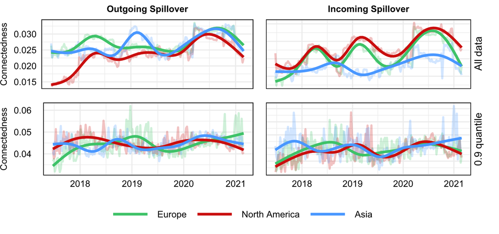

```r
e=ggarrange(a,b,c,d,ncol = 2, nrow = 2,common.legend = TRUE, legend="bottom")

ggsave(filename = "Continental over time Electronics.svg",
       plot = print(e),
       device = svg)

e
```

## Supply Chain Level Connectedness

We can not only aggregate based on country but also based on which “layer” of the supply chain the firm opperates

Calculate matrices, aggregating the spillover effects of individual firms to the supply chain level

- First regarding all spillover linkages

```r
SC_con=vector("list",(nrow(Vol_data_2)-w)/5)
for (i in 1:((nrow(Vol_data_2)-w)/5)){

  cont=matrix(0,8,8)


  cont[1,2]= sum(rowSums(Con_Matrices_2[[i]][grep("IP",plot_info[match(colnames(Con_Matrices_2[[i]]),names2),2]),grep("SME",plot_info[match(colnames(Con_Matrices_2[[i]]),names2),2])])/
                 rowSums(Con_Matrices_2[[i]][grep("IP",plot_info[match(colnames(Con_Matrices_2[[i]]),names2),2]),grep("SME",plot_info[match(colnames(Con_Matrices_2[[i]]),names2),2])]!=0))/
             sum(rowSums(Con_Matrices_2[[i]][grep("IP",plot_info[match(colnames(Con_Matrices_2[[i]]),names2),2]),grep("SME",plot_info[match(colnames(Con_Matrices_2[[i]]),names2),2])]!=0)!=0)

  cont[2,1]= sum(rowSums(Con_Matrices_2[[i]][grep("SME",plot_info[match(colnames(Con_Matrices_2[[i]]),names2),2]),grep("IP",plot_info[match(colnames(Con_Matrices_2[[i]]),names2),2])])/
                 rowSums(Con_Matrices_2[[i]][grep("SME",plot_info[match(colnames(Con_Matrices_2[[i]]),names2),2]),grep("IP",plot_info[match(colnames(Con_Matrices_2[[i]]),names2),2])]!=0))/
             sum(rowSums(Con_Matrices_2[[i]][grep("SME",plot_info[match(colnames(Con_Matrices_2[[i]]),names2),2]),grep("IP",plot_info[match(colnames(Con_Matrices_2[[i]]),names2),2])]!=0)!=0)

  cont[1,3]= sum(rowSums(Con_Matrices_2[[i]][grep("IP",plot_info[match(colnames(Con_Matrices_2[[i]]),names2),2]),grep("Foundry",plot_info[match(colnames(Con_Matrices_2[[i]]),names2),2])])/
                 rowSums(Con_Matrices_2[[i]][grep("IP",plot_info[match(colnames(Con_Matrices_2[[i]]),names2),2]),grep("Foundry",plot_info[match(colnames(Con_Matrices_2[[i]]),names2),2])]!=0))/
             sum(rowSums(Con_Matrices_2[[i]][grep("IP",plot_info[match(colnames(Con_Matrices_2[[i]]),names2),2]),grep("Foundry",plot_info[match(colnames(Con_Matrices_2[[i]]),names2),2])]!=0)!=0)

  cont[3,1]= sum(rowSums(Con_Matrices_2[[i]][grep("Foundry",plot_info[match(colnames(Con_Matrices_2[[i]]),names2),2]),grep("IP",plot_info[match(colnames(Con_Matrices_2[[i]]),names2),2])])/
                 rowSums(Con_Matrices_2[[i]][grep("Foundry",plot_info[match(colnames(Con_Matrices_2[[i]]),names2),2]),grep("IP",plot_info[match(colnames(Con_Matrices_2[[i]]),names2),2])]!=0))/
             sum(rowSums(Con_Matrices_2[[i]][grep("Foundry",plot_info[match(colnames(Con_Matrices_2[[i]]),names2),2]),grep("IP",plot_info[match(colnames(Con_Matrices_2[[i]]),names2),2])]!=0)!=0)

  cont[2,3]= sum(rowSums(Con_Matrices_2[[i]][grep("SME",plot_info[match(colnames(Con_Matrices_2[[i]]),names2),2]),grep("Foundry",plot_info[match(colnames(Con_Matrices_2[[i]]),names2),2])])/
                 rowSums(Con_Matrices_2[[i]][grep("SME",plot_info[match(colnames(Con_Matrices_2[[i]]),names2),2]),grep("Foundry",plot_info[match(colnames(Con_Matrices_2[[i]]),names2),2])]!=0))/
             sum(rowSums(Con_Matrices_2[[i]][grep("SME",plot_info[match(colnames(Con_Matrices_2[[i]]),names2),2]),grep("Foundry",plot_info[match(colnames(Con_Matrices_2[[i]]),names2),2])]!=0)!=0)

  cont[3,2]= sum(rowSums(Con_Matrices_2[[i]][grep("Foundry",plot_info[match(colnames(Con_Matrices_2[[i]]),names2),2]),grep("SME",plot_info[match(colnames(Con_Matrices_2[[i]]),names2),2])])/
                 rowSums(Con_Matrices_2[[i]][grep("Foundry",plot_info[match(colnames(Con_Matrices_2[[i]]),names2),2]),grep("SME",plot_info[match(colnames(Con_Matrices_2[[i]]),names2),2])]!=0))/
             sum(rowSums(Con_Matrices_2[[i]][grep("Foundry",plot_info[match(colnames(Con_Matrices_2[[i]]),names2),2]),grep("SME",plot_info[match(colnames(Con_Matrices_2[[i]]),names2),2])]!=0)!=0)

  cont[1,4]= sum(rowSums(Con_Matrices_2[[i]][grep("IP",plot_info[match(colnames(Con_Matrices_2[[i]]),names2),2]),grep("Fabless",plot_info[match(colnames(Con_Matrices_2[[i]]),names2),2])])/
                 rowSums(Con_Matrices_2[[i]][grep("IP",plot_info[match(colnames(Con_Matrices_2[[i]]),names2),2]),grep("Fabless",plot_info[match(colnames(Con_Matrices_2[[i]]),names2),2])]!=0))/
             sum(rowSums(Con_Matrices_2[[i]][grep("IP",plot_info[match(colnames(Con_Matrices_2[[i]]),names2),2]),grep("Fabless",plot_info[match(colnames(Con_Matrices_2[[i]]),names2),2])]!=0)!=0)

  cont[4,1]= sum(rowSums(Con_Matrices_2[[i]][grep("Fabless",plot_info[match(colnames(Con_Matrices_2[[i]]),names2),2]),grep("IP",plot_info[match(colnames(Con_Matrices_2[[i]]),names2),2])])/
                 rowSums(Con_Matrices_2[[i]][grep("Fabless",plot_info[match(colnames(Con_Matrices_2[[i]]),names2),2]),grep("IP",plot_info[match(colnames(Con_Matrices_2[[i]]),names2),2])]!=0))/
             sum(rowSums(Con_Matrices_2[[i]][grep("Fabless",plot_info[match(colnames(Con_Matrices_2[[i]]),names2),2]),grep("IP",plot_info[match(colnames(Con_Matrices_2[[i]]),names2),2])]!=0)!=0)

  cont[2,4]= sum(rowSums(Con_Matrices_2[[i]][grep("SME",plot_info[match(colnames(Con_Matrices_2[[i]]),names2),2]),grep("Fabless",plot_info[match(colnames(Con_Matrices_2[[i]]),names2),2])])/
                 rowSums(Con_Matrices_2[[i]][grep("SME",plot_info[match(colnames(Con_Matrices_2[[i]]),names2),2]),grep("Fabless",plot_info[match(colnames(Con_Matrices_2[[i]]),names2),2])]!=0))/
             sum(rowSums(Con_Matrices_2[[i]][grep("SME",plot_info[match(colnames(Con_Matrices_2[[i]]),names2),2]),grep("Fabless",plot_info[match(colnames(Con_Matrices_2[[i]]),names2),2])]!=0)!=0)

  cont[4,2]= sum(rowSums(Con_Matrices_2[[i]][grep("Fabless",plot_info[match(colnames(Con_Matrices_2[[i]]),names2),2]),grep("SME",plot_info[match(colnames(Con_Matrices_2[[i]]),names2),2])])/
                 rowSums(Con_Matrices_2[[i]][grep("Fabless",plot_info[match(colnames(Con_Matrices_2[[i]]),names2),2]),grep("SME",plot_info[match(colnames(Con_Matrices_2[[i]]),names2),2])]!=0))/
             sum(rowSums(Con_Matrices_2[[i]][grep("Fabless",plot_info[match(colnames(Con_Matrices_2[[i]]),names2),2]),grep("SME",plot_info[match(colnames(Con_Matrices_2[[i]]),names2),2])]!=0)!=0)

  cont[3,4]= sum(rowSums(Con_Matrices_2[[i]][grep("Foundry",plot_info[match(colnames(Con_Matrices_2[[i]]),names2),2]),grep("Fabless",plot_info[match(colnames(Con_Matrices_2[[i]]),names2),2])])/
                   rowSums(Con_Matrices_2[[i]][grep("Foundry",plot_info[match(colnames(Con_Matrices_2[[i]]),names2),2]),grep("Fabless",plot_info[match(colnames(Con_Matrices_2[[i]]),names2),2])]!=0))/
             sum(rowSums(Con_Matrices_2[[i]][grep("Foundry",plot_info[match(colnames(Con_Matrices_2[[i]]),names2),2]),grep("Fabless",plot_info[match(colnames(Con_Matrices_2[[i]]),names2),2])]!=0)!=0)
```

```r
  cont[4,3]= sum(rowSums(Con_Matrices_2[[i]][grep("Fabless",plot_info[match(colnames(Con_Matrices_2[[i]]),names2),2]),grep("Foundry",plot_info[match(colnames(Con_Matrices_2[[i]]),names2),2])])/
                   rowSums(Con_Matrices_2[[i]][grep("Fabless",plot_info[match(colnames(Con_Matrices_2[[i]]),names2),2]),grep("Foundry",plot_info[match(colnames(Con_Matrices_2[[i]]),names2),2])]!=0))/
             sum(rowSums(Con_Matrices_2[[i]][grep("Fabless",plot_info[match(colnames(Con_Matrices_2[[i]]),names2),2]),grep("Foundry",plot_info[match(colnames(Con_Matrices_2[[i]]),names2),2])]!=0)!=0)

  cont[1,5]= sum(rowSums(Con_Matrices_2[[i]][grep("IP",plot_info[match(colnames(Con_Matrices_2[[i]]),names2),2]),grep("IDM",plot_info[match(colnames(Con_Matrices_2[[i]]),names2),2])])/
                   rowSums(Con_Matrices_2[[i]][grep("IP",plot_info[match(colnames(Con_Matrices_2[[i]]),names2),2]),grep("IDM",plot_info[match(colnames(Con_Matrices_2[[i]]),names2),2])]!=0))/
             sum(rowSums(Con_Matrices_2[[i]][grep("IP",plot_info[match(colnames(Con_Matrices_2[[i]]),names2),2]),grep("IDM",plot_info[match(colnames(Con_Matrices_2[[i]]),names2),2])]!=0)!=0)

  cont[5,1]= sum(rowSums(Con_Matrices_2[[i]][grep("IDM",plot_info[match(colnames(Con_Matrices_2[[i]]),names2),2]),grep("IP",plot_info[match(colnames(Con_Matrices_2[[i]]),names2),2])])/
                   rowSums(Con_Matrices_2[[i]][grep("IDM",plot_info[match(colnames(Con_Matrices_2[[i]]),names2),2]),grep("IP",plot_info[match(colnames(Con_Matrices_2[[i]]),names2),2])]!=0))/
             sum(rowSums(Con_Matrices_2[[i]][grep("IDM",plot_info[match(colnames(Con_Matrices_2[[i]]),names2),2]),grep("IP",plot_info[match(colnames(Con_Matrices_2[[i]]),names2),2])]!=0)!=0)

  cont[2,5]= sum(rowSums(Con_Matrices_2[[i]][grep("SME",plot_info[match(colnames(Con_Matrices_2[[i]]),names2),2]),grep("IDM",plot_info[match(colnames(Con_Matrices_2[[i]]),names2),2])])/
                   rowSums(Con_Matrices_2[[i]][grep("SME",plot_info[match(colnames(Con_Matrices_2[[i]]),names2),2]),grep("IDM",plot_info[match(colnames(Con_Matrices_2[[i]]),names2),2])]!=0))/
             sum(rowSums(Con_Matrices_2[[i]][grep("SME",plot_info[match(colnames(Con_Matrices_2[[i]]),names2),2]),grep("IDM",plot_info[match(colnames(Con_Matrices_2[[i]]),names2),2])]!=0)!=0)

  cont[5,2]= sum(rowSums(Con_Matrices_2[[i]][grep("IDM",plot_info[match(colnames(Con_Matrices_2[[i]]),names2),2]),grep("SME",plot_info[match(colnames(Con_Matrices_2[[i]]),names2),2])])/
                   rowSums(Con_Matrices_2[[i]][grep("IDM",plot_info[match(colnames(Con_Matrices_2[[i]]),names2),2]),grep("SME",plot_info[match(colnames(Con_Matrices_2[[i]]),names2),2])]!=0))/
             sum(rowSums(Con_Matrices_2[[i]][grep("IDM",plot_info[match(colnames(Con_Matrices_2[[i]]),names2),2]),grep("SME",plot_info[match(colnames(Con_Matrices_2[[i]]),names2),2])]!=0)!=0)

  cont[3,5]= sum(rowSums(Con_Matrices_2[[i]][grep("Foundry",plot_info[match(colnames(Con_Matrices_2[[i]]),names2),2]),grep("IDM",plot_info[match(colnames(Con_Matrices_2[[i]]),names2),2])])/
                   rowSums(Con_Matrices_2[[i]][grep("Foundry",plot_info[match(colnames(Con_Matrices_2[[i]]),names2),2]),grep("IDM",plot_info[match(colnames(Con_Matrices_2[[i]]),names2),2])]!=0))/
             sum(rowSums(Con_Matrices_2[[i]][grep("Foundry",plot_info[match(colnames(Con_Matrices_2[[i]]),names2),2]),grep("IDM",plot_info[match(colnames(Con_Matrices_2[[i]]),names2),2])]!=0)!=0)

  cont[5,3]= sum(rowSums(Con_Matrices_2[[i]][grep("IDM",plot_info[match(colnames(Con_Matrices_2[[i]]),names2),2]),grep("Foundry",plot_info[match(colnames(Con_Matrices_2[[i]]),names2),2])])/
                   rowSums(Con_Matrices_2[[i]][grep("IDM",plot_info[match(colnames(Con_Matrices_2[[i]]),names2),2]),grep("Foundry",plot_info[match(colnames(Con_Matrices_2[[i]]),names2),2])]!=0))/
             sum(rowSums(Con_Matrices_2[[i]][grep("IDM",plot_info[match(colnames(Con_Matrices_2[[i]]),names2),2]),grep("Foundry",plot_info[match(colnames(Con_Matrices_2[[i]]),names2),2])]!=0)!=0)

  cont[5,4]= sum(rowSums(Con_Matrices_2[[i]][grep("IDM",plot_info[match(colnames(Con_Matrices_2[[i]]),names2),2]),grep("Fabless",plot_info[match(colnames(Con_Matrices_2[[i]]),names2),2])])/
                   rowSums(Con_Matrices_2[[i]][grep("IDM",plot_info[match(colnames(Con_Matrices_2[[i]]),names2),2]),grep("Fabless",plot_info[match(colnames(Con_Matrices_2[[i]]),names2),2])]!=0))/
             sum(rowSums(Con_Matrices_2[[i]][grep("IDM",plot_info[match(colnames(Con_Matrices_2[[i]]),names2),2]),grep("Fabless",plot_info[match(colnames(Con_Matrices_2[[i]]),names2),2])]!=0)!=0)

  cont[4,5]= sum(rowSums(Con_Matrices_2[[i]][grep("Fabless",plot_info[match(colnames(Con_Matrices_2[[i]]),names2),2]),grep("IDM",plot_info[match(colnames(Con_Matrices_2[[i]]),names2),2])])/
                   rowSums(Con_Matrices_2[[i]][grep("Fabless",plot_info[match(colnames(Con_Matrices_2[[i]]),names2),2]),grep("IDM",plot_info[match(colnames(Con_Matrices_2[[i]]),names2),2])]!=0))/
             sum(rowSums(Con_Matrices_2[[i]][grep("Fabless",plot_info[match(colnames(Con_Matrices_2[[i]]),names2),2]),grep("IDM",plot_info[match(colnames(Con_Matrices_2[[i]]),names2),2])]!=0)!=0)

  cont[1,6]= sum(rowSums(Con_Matrices_2[[i]][grep("IP",plot_info[match(colnames(Con_Matrices_2[[i]]),names2),2]),grep("OSAT",plot_info[match(colnames(Con_Matrices_2[[i]]),names2),2])])/
                   rowSums(Con_Matrices_2[[i]][grep("IP",plot_info[match(colnames(Con_Matrices_2[[i]]),names2),2]),grep("OSAT",plot_info[match(colnames(Con_Matrices_2[[i]]),names2),2])]!=0))/
             sum(rowSums(Con_Matrices_2[[i]][grep("IP",plot_info[match(colnames(Con_Matrices_2[[i]]),names2),2]),grep("OSAT",plot_info[match(colnames(Con_Matrices_2[[i]]),names2),2])]!=0)!=0)

  cont[6,1]= sum(rowSums(Con_Matrices_2[[i]][grep("OSAT",plot_info[match(colnames(Con_Matrices_2[[i]]),names2),2]),grep("IP",plot_info[match(colnames(Con_Matrices_2[[i]]),names2),2])])/
                   rowSums(Con_Matrices_2[[i]][grep("OSAT",plot_info[match(colnames(Con_Matrices_2[[i]]),names2),2]),grep("IP",plot_info[match(colnames(Con_Matrices_2[[i]]),names2),2])]!=0))/
             sum(rowSums(Con_Matrices_2[[i]][grep("OSAT",plot_info[match(colnames(Con_Matrices_2[[i]]),names2),2]),grep("IP",plot_info[match(colnames(Con_Matrices_2[[i]]),names2),2])]!=0)!=0)
```

```r
  cont[2,6]= sum(rowSums(Con_Matrices_2[[i]][grep("SME",plot_info[match(colnames(Con_Matrices_2[[i]]),names2),2]),grep("OSAT",plot_info[match(colnames(Con_Matrices_2[[i]]),names2),2])])/
                   rowSums(Con_Matrices_2[[i]][grep("SME",plot_info[match(colnames(Con_Matrices_2[[i]]),names2),2]),grep("OSAT",plot_info[match(colnames(Con_Matrices_2[[i]]),names2),2])]!=0))/
             sum(rowSums(Con_Matrices_2[[i]][grep("SME",plot_info[match(colnames(Con_Matrices_2[[i]]),names2),2]),grep("OSAT",plot_info[match(colnames(Con_Matrices_2[[i]]),names2),2])]!=0)!=0)

  cont[6,2]= sum(rowSums(Con_Matrices_2[[i]][grep("OSAT",plot_info[match(colnames(Con_Matrices_2[[i]]),names2),2]),grep("SME",plot_info[match(colnames(Con_Matrices_2[[i]]),names2),2])])/
                   rowSums(Con_Matrices_2[[i]][grep("OSAT",plot_info[match(colnames(Con_Matrices_2[[i]]),names2),2]),grep("SME",plot_info[match(colnames(Con_Matrices_2[[i]]),names2),2])]!=0))/
             sum(rowSums(Con_Matrices_2[[i]][grep("OSAT",plot_info[match(colnames(Con_Matrices_2[[i]]),names2),2]),grep("SME",plot_info[match(colnames(Con_Matrices_2[[i]]),names2),2])]!=0)!=0)

  cont[3,6]= sum(rowSums(Con_Matrices_2[[i]][grep("Foundry",plot_info[match(colnames(Con_Matrices_2[[i]]),names2),2]),grep("OSAT",plot_info[match(colnames(Con_Matrices_2[[i]]),names2),2])])/
                   rowSums(Con_Matrices_2[[i]][grep("Foundry",plot_info[match(colnames(Con_Matrices_2[[i]]),names2),2]),grep("OSAT",plot_info[match(colnames(Con_Matrices_2[[i]]),names2),2])]!=0))/
             sum(rowSums(Con_Matrices_2[[i]][grep("Foundry",plot_info[match(colnames(Con_Matrices_2[[i]]),names2),2]),grep("OSAT",plot_info[match(colnames(Con_Matrices_2[[i]]),names2),2])]!=0)!=0)

  cont[6,3]= sum(rowSums(Con_Matrices_2[[i]][grep("OSAT",plot_info[match(colnames(Con_Matrices_2[[i]]),names2),2]),grep("Foundry",plot_info[match(colnames(Con_Matrices_2[[i]]),names2),2])])/
                   rowSums(Con_Matrices_2[[i]][grep("OSAT",plot_info[match(colnames(Con_Matrices_2[[i]]),names2),2]),grep("Foundry",plot_info[match(colnames(Con_Matrices_2[[i]]),names2),2])]!=0))/
             sum(rowSums(Con_Matrices_2[[i]][grep("OSAT",plot_info[match(colnames(Con_Matrices_2[[i]]),names2),2]),grep("Foundry",plot_info[match(colnames(Con_Matrices_2[[i]]),names2),2])]!=0)!=0)

  cont[4,6]= sum(rowSums(Con_Matrices_2[[i]][grep("Fabless",plot_info[match(colnames(Con_Matrices_2[[i]]),names2),2]),grep("OSAT",plot_info[match(colnames(Con_Matrices_2[[i]]),names2),2])])/
                   rowSums(Con_Matrices_2[[i]][grep("Fabless",plot_info[match(colnames(Con_Matrices_2[[i]]),names2),2]),grep("OSAT",plot_info[match(colnames(Con_Matrices_2[[i]]),names2),2])]!=0))/
             sum(rowSums(Con_Matrices_2[[i]][grep("Fabless",plot_info[match(colnames(Con_Matrices_2[[i]]),names2),2]),grep("OSAT",plot_info[match(colnames(Con_Matrices_2[[i]]),names2),2])]!=0)!=0)

  cont[6,4]= sum(rowSums(Con_Matrices_2[[i]][grep("OSAT",plot_info[match(colnames(Con_Matrices_2[[i]]),names2),2]),grep("Fabless",plot_info[match(colnames(Con_Matrices_2[[i]]),names2),2])])/
                   rowSums(Con_Matrices_2[[i]][grep("OSAT",plot_info[match(colnames(Con_Matrices_2[[i]]),names2),2]),grep("Fabless",plot_info[match(colnames(Con_Matrices_2[[i]]),names2),2])]!=0))/
             sum(rowSums(Con_Matrices_2[[i]][grep("OSAT",plot_info[match(colnames(Con_Matrices_2[[i]]),names2),2]),grep("Fabless",plot_info[match(colnames(Con_Matrices_2[[i]]),names2),2])]!=0)!=0)

  cont[5,6]= sum(rowSums(Con_Matrices_2[[i]][grep("IDM",plot_info[match(colnames(Con_Matrices_2[[i]]),names2),2]),grep("OSAT",plot_info[match(colnames(Con_Matrices_2[[i]]),names2),2])])/
                   rowSums(Con_Matrices_2[[i]][grep("IDM",plot_info[match(colnames(Con_Matrices_2[[i]]),names2),2]),grep("OSAT",plot_info[match(colnames(Con_Matrices_2[[i]]),names2),2])]!=0))/
             sum(rowSums(Con_Matrices_2[[i]][grep("IDM",plot_info[match(colnames(Con_Matrices_2[[i]]),names2),2]),grep("OSAT",plot_info[match(colnames(Con_Matrices_2[[i]]),names2),2])]!=0)!=0)

  cont[6,5]= sum(rowSums(Con_Matrices_2[[i]][grep("OSAT",plot_info[match(colnames(Con_Matrices_2[[i]]),names2),2]),grep("IDM",plot_info[match(colnames(Con_Matrices_2[[i]]),names2),2])])/
                   rowSums(Con_Matrices_2[[i]][grep("OSAT",plot_info[match(colnames(Con_Matrices_2[[i]]),names2),2]),grep("IDM",plot_info[match(colnames(Con_Matrices_2[[i]]),names2),2])]!=0))/
             sum(rowSums(Con_Matrices_2[[i]][grep("OSAT",plot_info[match(colnames(Con_Matrices_2[[i]]),names2),2]),grep("IDM",plot_info[match(colnames(Con_Matrices_2[[i]]),names2),2])]!=0)!=0)

  cont[1,7]= sum(rowSums(Con_Matrices_2[[i]][grep("IP",plot_info[match(colnames(Con_Matrices_2[[i]]),names2),2]),grep("Sili",plot_info[match(colnames(Con_Matrices_2[[i]]),names2),2])])/
                   rowSums(Con_Matrices_2[[i]][grep("IP",plot_info[match(colnames(Con_Matrices_2[[i]]),names2),2]),grep("Sili",plot_info[match(colnames(Con_Matrices_2[[i]]),names2),2])]!=0))/
             sum(rowSums(Con_Matrices_2[[i]][grep("IP",plot_info[match(colnames(Con_Matrices_2[[i]]),names2),2]),grep("Sili",plot_info[match(colnames(Con_Matrices_2[[i]]),names2),2])]!=0)!=0)

  cont[7,1]= sum(rowSums(Con_Matrices_2[[i]][grep("Sili",plot_info[match(colnames(Con_Matrices_2[[i]]),names2),2]),grep("IP",plot_info[match(colnames(Con_Matrices_2[[i]]),names2),2])])/
                   rowSums(Con_Matrices_2[[i]][grep("Sili",plot_info[match(colnames(Con_Matrices_2[[i]]),names2),2]),grep("IP",plot_info[match(colnames(Con_Matrices_2[[i]]),names2),2])]!=0))/
             sum(rowSums(Con_Matrices_2[[i]][grep("Sili",plot_info[match(colnames(Con_Matrices_2[[i]]),names2),2]),grep("IP",plot_info[match(colnames(Con_Matrices_2[[i]]),names2),2])]!=0)!=0)

  cont[2,7]= sum(rowSums(Con_Matrices_2[[i]][grep("SME",plot_info[match(colnames(Con_Matrices_2[[i]]),names2),2]),grep("Sili",plot_info[match(colnames(Con_Matrices_2[[i]]),names2),2])])/
                   rowSums(Con_Matrices_2[[i]][grep("SME",plot_info[match(colnames(Con_Matrices_2[[i]]),names2),2]),grep("Sili",plot_info[match(colnames(Con_Matrices_2[[i]]),names2),2])]!=0))/
             sum(rowSums(Con_Matrices_2[[i]][grep("SME",plot_info[match(colnames(Con_Matrices_2[[i]]),names2),2]),grep("Sili",plot_info[match(colnames(Con_Matrices_2[[i]]),names2),2])]!=0)!=0)
```

```r
  cont[7,2]= sum(rowSums(Con_Matrices_2[[i]][grep("Sili",plot_info[match(colnames(Con_Matrices_2[[i]]),names2),2]),grep("SME",plot_info[match(colnames(Con_Matrices_2[[i]]),names2),2])])/
                   rowSums(Con_Matrices_2[[i]][grep("Sili",plot_info[match(colnames(Con_Matrices_2[[i]]),names2),2]),grep("SME",plot_info[match(colnames(Con_Matrices_2[[i]]),names2),2])]!=0))/
             sum(rowSums(Con_Matrices_2[[i]][grep("Sili",plot_info[match(colnames(Con_Matrices_2[[i]]),names2),2]),grep("SME",plot_info[match(colnames(Con_Matrices_2[[i]]),names2),2])]!=0)!=0)

  cont[3,7]= sum(rowSums(Con_Matrices_2[[i]][grep("Foundry",plot_info[match(colnames(Con_Matrices_2[[i]]),names2),2]),grep("Sili",plot_info[match(colnames(Con_Matrices_2[[i]]),names2),2])])/
                   rowSums(Con_Matrices_2[[i]][grep("Foundry",plot_info[match(colnames(Con_Matrices_2[[i]]),names2),2]),grep("Sili",plot_info[match(colnames(Con_Matrices_2[[i]]),names2),2])]!=0))/
             sum(rowSums(Con_Matrices_2[[i]][grep("Foundry",plot_info[match(colnames(Con_Matrices_2[[i]]),names2),2]),grep("Sili",plot_info[match(colnames(Con_Matrices_2[[i]]),names2),2])]!=0)!=0)

  cont[7,3]= sum(rowSums(Con_Matrices_2[[i]][grep("Sili",plot_info[match(colnames(Con_Matrices_2[[i]]),names2),2]),grep("Foundry",plot_info[match(colnames(Con_Matrices_2[[i]]),names2),2])])/
                   rowSums(Con_Matrices_2[[i]][grep("Sili",plot_info[match(colnames(Con_Matrices_2[[i]]),names2),2]),grep("Foundry",plot_info[match(colnames(Con_Matrices_2[[i]]),names2),2])]!=0))/
             sum(rowSums(Con_Matrices_2[[i]][grep("Sili",plot_info[match(colnames(Con_Matrices_2[[i]]),names2),2]),grep("Foundry",plot_info[match(colnames(Con_Matrices_2[[i]]),names2),2])]!=0)!=0)

  cont[4,7]= sum(rowSums(Con_Matrices_2[[i]][grep("Fabless",plot_info[match(colnames(Con_Matrices_2[[i]]),names2),2]),grep("Sili",plot_info[match(colnames(Con_Matrices_2[[i]]),names2),2])])/
                   rowSums(Con_Matrices_2[[i]][grep("Fabless",plot_info[match(colnames(Con_Matrices_2[[i]]),names2),2]),grep("Sili",plot_info[match(colnames(Con_Matrices_2[[i]]),names2),2])]!=0))/
             sum(rowSums(Con_Matrices_2[[i]][grep("Fabless",plot_info[match(colnames(Con_Matrices_2[[i]]),names2),2]),grep("Sili",plot_info[match(colnames(Con_Matrices_2[[i]]),names2),2])]!=0)!=0)

  cont[7,4]= sum(rowSums(Con_Matrices_2[[i]][grep("Sili",plot_info[match(colnames(Con_Matrices_2[[i]]),names2),2]),grep("Fabless",plot_info[match(colnames(Con_Matrices_2[[i]]),names2),2])])/
                   rowSums(Con_Matrices_2[[i]][grep("Sili",plot_info[match(colnames(Con_Matrices_2[[i]]),names2),2]),grep("Fabless",plot_info[match(colnames(Con_Matrices_2[[i]]),names2),2])]!=0))/
             sum(rowSums(Con_Matrices_2[[i]][grep("Sili",plot_info[match(colnames(Con_Matrices_2[[i]]),names2),2]),grep("Fabless",plot_info[match(colnames(Con_Matrices_2[[i]]),names2),2])]!=0)!=0)

  cont[5,7]= sum(rowSums(Con_Matrices_2[[i]][grep("IDM",plot_info[match(colnames(Con_Matrices_2[[i]]),names2),2]),grep("Sili",plot_info[match(colnames(Con_Matrices_2[[i]]),names2),2])])/
                   rowSums(Con_Matrices_2[[i]][grep("IDM",plot_info[match(colnames(Con_Matrices_2[[i]]),names2),2]),grep("Sili",plot_info[match(colnames(Con_Matrices_2[[i]]),names2),2])]!=0))/
             sum(rowSums(Con_Matrices_2[[i]][grep("IDM",plot_info[match(colnames(Con_Matrices_2[[i]]),names2),2]),grep("Sili",plot_info[match(colnames(Con_Matrices_2[[i]]),names2),2])]!=0)!=0)

  cont[7,5]= sum(rowSums(Con_Matrices_2[[i]][grep("Sili",plot_info[match(colnames(Con_Matrices_2[[i]]),names2),2]),grep("IDM",plot_info[match(colnames(Con_Matrices_2[[i]]),names2),2])])/
                   rowSums(Con_Matrices_2[[i]][grep("Sili",plot_info[match(colnames(Con_Matrices_2[[i]]),names2),2]),grep("IDM",plot_info[match(colnames(Con_Matrices_2[[i]]),names2),2])]!=0))/
             sum(rowSums(Con_Matrices_2[[i]][grep("Sili",plot_info[match(colnames(Con_Matrices_2[[i]]),names2),2]),grep("IDM",plot_info[match(colnames(Con_Matrices_2[[i]]),names2),2])]!=0)!=0)

  cont[6,7]= sum(rowSums(Con_Matrices_2[[i]][grep("OSAT",plot_info[match(colnames(Con_Matrices_2[[i]]),names2),2]),grep("Sili",plot_info[match(colnames(Con_Matrices_2[[i]]),names2),2])])/
                   rowSums(Con_Matrices_2[[i]][grep("OSAT",plot_info[match(colnames(Con_Matrices_2[[i]]),names2),2]),grep("Sili",plot_info[match(colnames(Con_Matrices_2[[i]]),names2),2])]!=0))/
             sum(rowSums(Con_Matrices_2[[i]][grep("OSAT",plot_info[match(colnames(Con_Matrices_2[[i]]),names2),2]),grep("Sili",plot_info[match(colnames(Con_Matrices_2[[i]]),names2),2])]!=0)!=0)

  cont[7,6]= sum(rowSums(Con_Matrices_2[[i]][grep("Sili",plot_info[match(colnames(Con_Matrices_2[[i]]),names2),2]),grep("OSAT",plot_info[match(colnames(Con_Matrices_2[[i]]),names2),2])])/
                   rowSums(Con_Matrices_2[[i]][grep("Sili",plot_info[match(colnames(Con_Matrices_2[[i]]),names2),2]),grep("OSAT",plot_info[match(colnames(Con_Matrices_2[[i]]),names2),2])]!=0))/
             sum(rowSums(Con_Matrices_2[[i]][grep("Sili",plot_info[match(colnames(Con_Matrices_2[[i]]),names2),2]),grep("OSAT",plot_info[match(colnames(Con_Matrices_2[[i]]),names2),2])]!=0)!=0)

  cont[which(is.nan(cont))]<-0

  #To others
  cont[1,8]= sum(cont[1,2],cont[1,3],cont[1,4],cont[1,5],cont[1,6],cont[1,7])/3
  cont[2,8]= sum(cont[2,1],cont[2,3],cont[2,4],cont[2,5],cont[2,6],cont[2,7])/4
  cont[3,8]= sum(cont[3,1],cont[3,2],cont[3,4],cont[3,5],cont[3,6],cont[3,7])/5
  cont[4,8]= sum(cont[4,1],cont[4,2],cont[4,3],cont[4,5],cont[4,6],cont[4,7])/4
  cont[5,8]= sum(cont[5,1],cont[5,2],cont[5,3],cont[5,4],cont[5,6],cont[5,7])/4
  cont[6,8]= sum(cont[6,1],cont[6,2],cont[6,3],cont[6,4],cont[6,5],cont[6,7])/4
  cont[7,8]= sum(cont[7,1],cont[7,2],cont[7,3],cont[7,4],cont[7,5],cont[7,6])/4


  #From others
  cont[8,1]= sum(cont[2,1],cont[3,1],cont[4,1],cont[5,1],cont[6,1],cont[7,1])/3
  cont[8,2]= sum(cont[1,2],cont[3,2],cont[4,2],cont[5,2],cont[6,2],cont[7,2])/4
  cont[8,3]= sum(cont[1,3],cont[2,3],cont[4,3],cont[5,3],cont[6,3],cont[7,3])/5
  cont[8,4]= sum(cont[1,4],cont[2,4],cont[3,4],cont[5,4],cont[6,4],cont[7,4])/4
  cont[8,5]= sum(cont[1,5],cont[2,5],cont[3,5],cont[4,5],cont[6,5],cont[7,5])/4
  cont[8,6]= sum(cont[1,6],cont[2,6],cont[3,6],cont[4,6],cont[5,6],cont[7,6])/4
  cont[8,7]= sum(cont[1,7],cont[2,7],cont[3,7],cont[4,7],cont[5,7],cont[6,7])/4
```

```r
  #Total Con
  cont[8,8]= sum(colSums(Con_Matrices_2[[i]]))

  SC_con[[i]]=cont
}
```

- Second only regarding the n-largest spillover linkages

```r
SC_con_N=vector("list",(nrow(Vol_data_2)-w)/5)
for (i in 1:((nrow(Vol_data_2)-w)/5)){

  cont=matrix(0,8,8)

  cont[1,2]= sum(rowSums(Con_Matrices_TopN[[i]][grep("IP",plot_info[match(colnames(Con_Matrices_TopN[[i]]),names2),2]),grep("SME",plot_info[match(colnames(Con_Matrices_TopN[[i]]),names2),2]),drop=FALSE])/
                 rowSums(Con_Matrices_TopN[[i]][grep("IP",plot_info[match(colnames(Con_Matrices_TopN[[i]]),names2),2]),grep("SME",plot_info[match(colnames(Con_Matrices_TopN[[i]]),names2),2]),drop=FALSE]!=0),na.rm = T)/
             sum(rowSums(Con_Matrices_TopN[[i]][grep("IP",plot_info[match(colnames(Con_Matrices_TopN[[i]]),names2),2]),grep("SME",plot_info[match(colnames(Con_Matrices_TopN[[i]]),names2),2]),drop=FALSE]!=0)!=0)

  cont[2,1]= sum(rowSums(Con_Matrices_TopN[[i]][grep("SME",plot_info[match(colnames(Con_Matrices_TopN[[i]]),names2),2]),grep("IP",plot_info[match(colnames(Con_Matrices_TopN[[i]]),names2),2]),drop=FALSE])/
                 rowSums(Con_Matrices_TopN[[i]][grep("SME",plot_info[match(colnames(Con_Matrices_TopN[[i]]),names2),2]),grep("IP",plot_info[match(colnames(Con_Matrices_TopN[[i]]),names2),2]),drop=FALSE]!=0),na.rm = T)/
             sum(rowSums(Con_Matrices_TopN[[i]][grep("SME",plot_info[match(colnames(Con_Matrices_TopN[[i]]),names2),2]),grep("IP",plot_info[match(colnames(Con_Matrices_TopN[[i]]),names2),2]),drop=FALSE]!=0)!=0)

  cont[1,3]= sum(rowSums(Con_Matrices_TopN[[i]][grep("IP",plot_info[match(colnames(Con_Matrices_TopN[[i]]),names2),2]),grep("Foundry",plot_info[match(colnames(Con_Matrices_TopN[[i]]),names2),2]),drop=FALSE])/
                 rowSums(Con_Matrices_TopN[[i]][grep("IP",plot_info[match(colnames(Con_Matrices_TopN[[i]]),names2),2]),grep("Foundry",plot_info[match(colnames(Con_Matrices_TopN[[i]]),names2),2]),drop=FALSE]!=0),na.rm = T)/
             sum(rowSums(Con_Matrices_TopN[[i]][grep("IP",plot_info[match(colnames(Con_Matrices_TopN[[i]]),names2),2]),grep("Foundry",plot_info[match(colnames(Con_Matrices_TopN[[i]]),names2),2]),drop=FALSE]!=0)!=0)

  cont[3,1]= sum(rowSums(Con_Matrices_TopN[[i]][grep("Foundry",plot_info[match(colnames(Con_Matrices_TopN[[i]]),names2),2]),grep("IP",plot_info[match(colnames(Con_Matrices_TopN[[i]]),names2),2]),drop=FALSE])/
                 rowSums(Con_Matrices_TopN[[i]][grep("Foundry",plot_info[match(colnames(Con_Matrices_TopN[[i]]),names2),2]),grep("IP",plot_info[match(colnames(Con_Matrices_TopN[[i]]),names2),2]),drop=FALSE]!=0),na.rm = T)/
             sum(rowSums(Con_Matrices_TopN[[i]][grep("Foundry",plot_info[match(colnames(Con_Matrices_TopN[[i]]),names2),2]),grep("IP",plot_info[match(colnames(Con_Matrices_TopN[[i]]),names2),2]),drop=FALSE]!=0)!=0)

  cont[2,3]= sum(rowSums(Con_Matrices_TopN[[i]][grep("SME",plot_info[match(colnames(Con_Matrices_TopN[[i]]),names2),2]),grep("Foundry",plot_info[match(colnames(Con_Matrices_TopN[[i]]),names2),2]),drop=FALSE])/
                 rowSums(Con_Matrices_TopN[[i]][grep("SME",plot_info[match(colnames(Con_Matrices_TopN[[i]]),names2),2]),grep("Foundry",plot_info[match(colnames(Con_Matrices_TopN[[i]]),names2),2]),drop=FALSE]!=0),na.rm = T)/
             sum(rowSums(Con_Matrices_TopN[[i]][grep("SME",plot_info[match(colnames(Con_Matrices_TopN[[i]]),names2),2]),grep("Foundry",plot_info[match(colnames(Con_Matrices_TopN[[i]]),names2),2]),drop=FALSE]!=0)!=0)

  cont[3,2]= sum(rowSums(Con_Matrices_TopN[[i]][grep("Foundry",plot_info[match(colnames(Con_Matrices_TopN[[i]]),names2),2]),grep("SME",plot_info[match(colnames(Con_Matrices_TopN[[i]]),names2),2]),drop=FALSE])/
                 rowSums(Con_Matrices_TopN[[i]][grep("Foundry",plot_info[match(colnames(Con_Matrices_TopN[[i]]),names2),2]),grep("SME",plot_info[match(colnames(Con_Matrices_TopN[[i]]),names2),2]),drop=FALSE]!=0),na.rm = T)/
             sum(rowSums(Con_Matrices_TopN[[i]][grep("Foundry",plot_info[match(colnames(Con_Matrices_TopN[[i]]),names2),2]),grep("SME",plot_info[match(colnames(Con_Matrices_TopN[[i]]),names2),2]),drop=FALSE]!=0)!=0)

  cont[1,4]= sum(rowSums(Con_Matrices_TopN[[i]][grep("IP",plot_info[match(colnames(Con_Matrices_TopN[[i]]),names2),2]),grep("Fabless",plot_info[match(colnames(Con_Matrices_TopN[[i]]),names2),2]),drop=FALSE])/
                 rowSums(Con_Matrices_TopN[[i]][grep("IP",plot_info[match(colnames(Con_Matrices_TopN[[i]]),names2),2]),grep("Fabless",plot_info[match(colnames(Con_Matrices_TopN[[i]]),names2),2]),drop=FALSE]!=0),na.rm = T)/
             sum(rowSums(Con_Matrices_TopN[[i]][grep("IP",plot_info[match(colnames(Con_Matrices_TopN[[i]]),names2),2]),grep("Fabless",plot_info[match(colnames(Con_Matrices_TopN[[i]]),names2),2]),drop=FALSE]!=0)!=0)

  cont[4,1]= sum(rowSums(Con_Matrices_TopN[[i]][grep("Fabless",plot_info[match(colnames(Con_Matrices_TopN[[i]]),names2),2]),grep("IP",plot_info[match(colnames(Con_Matrices_TopN[[i]]),names2),2]),drop=FALSE])/
                 rowSums(Con_Matrices_TopN[[i]][grep("Fabless",plot_info[match(colnames(Con_Matrices_TopN[[i]]),names2),2]),grep("IP",plot_info[match(colnames(Con_Matrices_TopN[[i]]),names2),2]),drop=FALSE]!=0),na.rm = T)/
             sum(rowSums(Con_Matrices_TopN[[i]][grep("Fabless",plot_info[match(colnames(Con_Matrices_TopN[[i]]),names2),2]),grep("IP",plot_info[match(colnames(Con_Matrices_TopN[[i]]),names2),2]),drop=FALSE]!=0)!=0)

  cont[2,4]= sum(rowSums(Con_Matrices_TopN[[i]][grep("SME",plot_info[match(colnames(Con_Matrices_TopN[[i]]),names2),2]),grep("Fabless",plot_info[match(colnames(Con_Matrices_TopN[[i]]),names2),2]),drop=FALSE])/
                 rowSums(Con_Matrices_TopN[[i]][grep("SME",plot_info[match(colnames(Con_Matrices_TopN[[i]]),names2),2]),grep("Fabless",plot_info[match(colnames(Con_Matrices_TopN[[i]]),names2),2]),drop=FALSE]!=0),na.rm = T)/
             sum(rowSums(Con_Matrices_TopN[[i]][grep("SME",plot_info[match(colnames(Con_Matrices_TopN[[i]]),names2),2]),grep("Fabless",plot_info[match(colnames(Con_Matrices_TopN[[i]]),names2),2]),drop=FALSE]!=0)!=0)

  cont[4,2]= sum(rowSums(Con_Matrices_TopN[[i]][grep("Fabless",plot_info[match(colnames(Con_Matrices_TopN[[i]]),names2),2]),grep("SME",plot_info[match(colnames(Con_Matrices_TopN[[i]]),names2),2]),drop=FALSE])/
                 rowSums(Con_Matrices_TopN[[i]][grep("Fabless",plot_info[match(colnames(Con_Matrices_TopN[[i]]),names2),2]),grep("SME",plot_info[match(colnames(Con_Matrices_TopN[[i]]),names2),2]),drop=FALSE]!=0),na.rm = T)/
             sum(rowSums(Con_Matrices_TopN[[i]][grep("Fabless",plot_info[match(colnames(Con_Matrices_TopN[[i]]),names2),2]),grep("SME",plot_info[match(colnames(Con_Matrices_TopN[[i]]),names2),2]),drop=FALSE]!=0)!=0)
```

```r
  cont[3,4]= sum(rowSums(Con_Matrices_TopN[[i]][grep("Foundry",plot_info[match(colnames(Con_Matrices_TopN[[i]]),names2),2]),grep("Fabless",plot_info[match(colnames(Con_Matrices_TopN[[i]]),names2),2]),drop=FALSE])/
                 rowSums(Con_Matrices_TopN[[i]][grep("Foundry",plot_info[match(colnames(Con_Matrices_TopN[[i]]),names2),2]),grep("Fabless",plot_info[match(colnames(Con_Matrices_TopN[[i]]),names2),2]),drop=FALSE]!=0),na.rm = T)/
             sum(rowSums(Con_Matrices_TopN[[i]][grep("Foundry",plot_info[match(colnames(Con_Matrices_TopN[[i]]),names2),2]),grep("Fabless",plot_info[match(colnames(Con_Matrices_TopN[[i]]),names2),2]),drop=FALSE]!=0)!=0)

  cont[4,3]= sum(rowSums(Con_Matrices_TopN[[i]][grep("Fabless",plot_info[match(colnames(Con_Matrices_TopN[[i]]),names2),2]),grep("Foundry",plot_info[match(colnames(Con_Matrices_TopN[[i]]),names2),2]),drop=FALSE])/
                 rowSums(Con_Matrices_TopN[[i]][grep("Fabless",plot_info[match(colnames(Con_Matrices_TopN[[i]]),names2),2]),grep("Foundry",plot_info[match(colnames(Con_Matrices_TopN[[i]]),names2),2]),drop=FALSE]!=0),na.rm = T)/
             sum(rowSums(Con_Matrices_TopN[[i]][grep("Fabless",plot_info[match(colnames(Con_Matrices_TopN[[i]]),names2),2]),grep("Foundry",plot_info[match(colnames(Con_Matrices_TopN[[i]]),names2),2]),drop=FALSE]!=0)!=0)

  cont[1,5]= sum(rowSums(Con_Matrices_TopN[[i]][grep("IP",plot_info[match(colnames(Con_Matrices_TopN[[i]]),names2),2]),grep("IDM",plot_info[match(colnames(Con_Matrices_TopN[[i]]),names2),2]),drop=FALSE])/
                 rowSums(Con_Matrices_TopN[[i]][grep("IP",plot_info[match(colnames(Con_Matrices_TopN[[i]]),names2),2]),grep("IDM",plot_info[match(colnames(Con_Matrices_TopN[[i]]),names2),2]),drop=FALSE]!=0),na.rm = T)/
             sum(rowSums(Con_Matrices_TopN[[i]][grep("IP",plot_info[match(colnames(Con_Matrices_TopN[[i]]),names2),2]),grep("IDM",plot_info[match(colnames(Con_Matrices_TopN[[i]]),names2),2]),drop=FALSE]!=0)!=0)

  cont[5,1]= sum(rowSums(Con_Matrices_TopN[[i]][grep("IDM",plot_info[match(colnames(Con_Matrices_TopN[[i]]),names2),2]),grep("IP",plot_info[match(colnames(Con_Matrices_TopN[[i]]),names2),2]),drop=FALSE])/
                 rowSums(Con_Matrices_TopN[[i]][grep("IDM",plot_info[match(colnames(Con_Matrices_TopN[[i]]),names2),2]),grep("IP",plot_info[match(colnames(Con_Matrices_TopN[[i]]),names2),2]),drop=FALSE]!=0),na.rm = T)/
             sum(rowSums(Con_Matrices_TopN[[i]][grep("IDM",plot_info[match(colnames(Con_Matrices_TopN[[i]]),names2),2]),grep("IP",plot_info[match(colnames(Con_Matrices_TopN[[i]]),names2),2]),drop=FALSE]!=0)!=0)

  cont[2,5]= sum(rowSums(Con_Matrices_TopN[[i]][grep("SME",plot_info[match(colnames(Con_Matrices_TopN[[i]]),names2),2]),grep("IDM",plot_info[match(colnames(Con_Matrices_TopN[[i]]),names2),2]),drop=FALSE])/
                 rowSums(Con_Matrices_TopN[[i]][grep("SME",plot_info[match(colnames(Con_Matrices_TopN[[i]]),names2),2]),grep("IDM",plot_info[match(colnames(Con_Matrices_TopN[[i]]),names2),2]),drop=FALSE]!=0),na.rm = T)/
             sum(rowSums(Con_Matrices_TopN[[i]][grep("SME",plot_info[match(colnames(Con_Matrices_TopN[[i]]),names2),2]),grep("IDM",plot_info[match(colnames(Con_Matrices_TopN[[i]]),names2),2]),drop=FALSE]!=0)!=0)

  cont[5,2]= sum(rowSums(Con_Matrices_TopN[[i]][grep("IDM",plot_info[match(colnames(Con_Matrices_TopN[[i]]),names2),2]),grep("SME",plot_info[match(colnames(Con_Matrices_TopN[[i]]),names2),2]),drop=FALSE])/
                 rowSums(Con_Matrices_TopN[[i]][grep("IDM",plot_info[match(colnames(Con_Matrices_TopN[[i]]),names2),2]),grep("SME",plot_info[match(colnames(Con_Matrices_TopN[[i]]),names2),2]),drop=FALSE]!=0),na.rm = T)/
             sum(rowSums(Con_Matrices_TopN[[i]][grep("IDM",plot_info[match(colnames(Con_Matrices_TopN[[i]]),names2),2]),grep("SME",plot_info[match(colnames(Con_Matrices_TopN[[i]]),names2),2]),drop=FALSE]!=0)!=0)

  cont[3,5]= sum(rowSums(Con_Matrices_TopN[[i]][grep("Foundry",plot_info[match(colnames(Con_Matrices_TopN[[i]]),names2),2]),grep("IDM",plot_info[match(colnames(Con_Matrices_TopN[[i]]),names2),2]),drop=FALSE])/
                 rowSums(Con_Matrices_TopN[[i]][grep("Foundry",plot_info[match(colnames(Con_Matrices_TopN[[i]]),names2),2]),grep("IDM",plot_info[match(colnames(Con_Matrices_TopN[[i]]),names2),2]),drop=FALSE]!=0),na.rm = T)/
             sum(rowSums(Con_Matrices_TopN[[i]][grep("Foundry",plot_info[match(colnames(Con_Matrices_TopN[[i]]),names2),2]),grep("IDM",plot_info[match(colnames(Con_Matrices_TopN[[i]]),names2),2]),drop=FALSE]!=0)!=0)

  cont[5,3]= sum(rowSums(Con_Matrices_TopN[[i]][grep("IDM",plot_info[match(colnames(Con_Matrices_TopN[[i]]),names2),2]),grep("Foundry",plot_info[match(colnames(Con_Matrices_TopN[[i]]),names2),2]),drop=FALSE])/
                 rowSums(Con_Matrices_TopN[[i]][grep("IDM",plot_info[match(colnames(Con_Matrices_TopN[[i]]),names2),2]),grep("Foundry",plot_info[match(colnames(Con_Matrices_TopN[[i]]),names2),2]),drop=FALSE]!=0),na.rm = T)/
             sum(rowSums(Con_Matrices_TopN[[i]][grep("IDM",plot_info[match(colnames(Con_Matrices_TopN[[i]]),names2),2]),grep("Foundry",plot_info[match(colnames(Con_Matrices_TopN[[i]]),names2),2]),drop=FALSE]!=0)!=0)

  cont[5,4]= sum(rowSums(Con_Matrices_TopN[[i]][grep("IDM",plot_info[match(colnames(Con_Matrices_TopN[[i]]),names2),2]),grep("Fabless",plot_info[match(colnames(Con_Matrices_TopN[[i]]),names2),2]),drop=FALSE])/
                 rowSums(Con_Matrices_TopN[[i]][grep("IDM",plot_info[match(colnames(Con_Matrices_TopN[[i]]),names2),2]),grep("Fabless",plot_info[match(colnames(Con_Matrices_TopN[[i]]),names2),2]),drop=FALSE]!=0),na.rm = T)/
            sum(rowSums(Con_Matrices_TopN[[i]][grep("IDM",plot_info[match(colnames(Con_Matrices_TopN[[i]]),names2),2]),grep("Fabless",plot_info[match(colnames(Con_Matrices_TopN[[i]]),names2),2]),drop=FALSE]!=0)!=0)

  cont[4,5]= sum(rowSums(Con_Matrices_TopN[[i]][grep("Fabless",plot_info[match(colnames(Con_Matrices_TopN[[i]]),names2),2]),grep("IDM",plot_info[match(colnames(Con_Matrices_TopN[[i]]),names2),2]),drop=FALSE])/
                 rowSums(Con_Matrices_TopN[[i]][grep("Fabless",plot_info[match(colnames(Con_Matrices_TopN[[i]]),names2),2]),grep("IDM",plot_info[match(colnames(Con_Matrices_TopN[[i]]),names2),2]),drop=FALSE]!=0),na.rm = T)/
             sum(rowSums(Con_Matrices_TopN[[i]][grep("Fabless",plot_info[match(colnames(Con_Matrices_TopN[[i]]),names2),2]),grep("IDM",plot_info[match(colnames(Con_Matrices_TopN[[i]]),names2),2]),drop=FALSE]!=0)!=0)
```

```r
  cont[1,6]= sum(rowSums(Con_Matrices_TopN[[i]][grep("IP",plot_info[match(colnames(Con_Matrices_TopN[[i]]),names2),2]),grep("OSAT",plot_info[match(colnames(Con_Matrices_TopN[[i]]),names2),2]),drop=FALSE])/
                 rowSums(Con_Matrices_TopN[[i]][grep("IP",plot_info[match(colnames(Con_Matrices_TopN[[i]]),names2),2]),grep("OSAT",plot_info[match(colnames(Con_Matrices_TopN[[i]]),names2),2]),drop=FALSE]!=0),na.rm = T)/
             sum(rowSums(Con_Matrices_TopN[[i]][grep("IP",plot_info[match(colnames(Con_Matrices_TopN[[i]]),names2),2]),grep("OSAT",plot_info[match(colnames(Con_Matrices_TopN[[i]]),names2),2]),drop=FALSE]!=0)!=0)

  cont[6,1]= sum(rowSums(Con_Matrices_TopN[[i]][grep("OSAT",plot_info[match(colnames(Con_Matrices_TopN[[i]]),names2),2]),grep("IP",plot_info[match(colnames(Con_Matrices_TopN[[i]]),names2),2]),drop=FALSE])/
                 rowSums(Con_Matrices_TopN[[i]][grep("OSAT",plot_info[match(colnames(Con_Matrices_TopN[[i]]),names2),2]),grep("IP",plot_info[match(colnames(Con_Matrices_TopN[[i]]),names2),2]),drop=FALSE]!=0),na.rm = T)/
             sum(rowSums(Con_Matrices_TopN[[i]][grep("OSAT",plot_info[match(colnames(Con_Matrices_TopN[[i]]),names2),2]),grep("IP",plot_info[match(colnames(Con_Matrices_TopN[[i]]),names2),2]),drop=FALSE]!=0)!=0)

  cont[2,6]= sum(rowSums(Con_Matrices_TopN[[i]][grep("SME",plot_info[match(colnames(Con_Matrices_TopN[[i]]),names2),2]),grep("OSAT",plot_info[match(colnames(Con_Matrices_TopN[[i]]),names2),2]),drop=FALSE])/
                 rowSums(Con_Matrices_TopN[[i]][grep("SME",plot_info[match(colnames(Con_Matrices_TopN[[i]]),names2),2]),grep("OSAT",plot_info[match(colnames(Con_Matrices_TopN[[i]]),names2),2]),drop=FALSE]!=0),na.rm = T)/
             sum(rowSums(Con_Matrices_TopN[[i]][grep("SME",plot_info[match(colnames(Con_Matrices_TopN[[i]]),names2),2]),grep("OSAT",plot_info[match(colnames(Con_Matrices_TopN[[i]]),names2),2]),drop=FALSE]!=0)!=0)

  cont[6,2]= sum(rowSums(Con_Matrices_TopN[[i]][grep("OSAT",plot_info[match(colnames(Con_Matrices_TopN[[i]]),names2),2]),grep("SME",plot_info[match(colnames(Con_Matrices_TopN[[i]]),names2),2]),drop=FALSE])/
                 rowSums(Con_Matrices_TopN[[i]][grep("OSAT",plot_info[match(colnames(Con_Matrices_TopN[[i]]),names2),2]),grep("SME",plot_info[match(colnames(Con_Matrices_TopN[[i]]),names2),2]),drop=FALSE]!=0),na.rm = T)/
             sum(rowSums(Con_Matrices_TopN[[i]][grep("OSAT",plot_info[match(colnames(Con_Matrices_TopN[[i]]),names2),2]),grep("SME",plot_info[match(colnames(Con_Matrices_TopN[[i]]),names2),2]),drop=FALSE]!=0)!=0)

  cont[3,6]= sum(rowSums(Con_Matrices_TopN[[i]][grep("Foundry",plot_info[match(colnames(Con_Matrices_TopN[[i]]),names2),2]),grep("OSAT",plot_info[match(colnames(Con_Matrices_TopN[[i]]),names2),2]),drop=FALSE])/
                 rowSums(Con_Matrices_TopN[[i]][grep("Foundry",plot_info[match(colnames(Con_Matrices_TopN[[i]]),names2),2]),grep("OSAT",plot_info[match(colnames(Con_Matrices_TopN[[i]]),names2),2]),drop=FALSE]!=0),na.rm = T)/
             sum(rowSums(Con_Matrices_TopN[[i]][grep("Foundry",plot_info[match(colnames(Con_Matrices_TopN[[i]]),names2),2]),grep("OSAT",plot_info[match(colnames(Con_Matrices_TopN[[i]]),names2),2]),drop=FALSE]!=0)!=0)

  cont[6,3]= sum(rowSums(Con_Matrices_TopN[[i]][grep("OSAT",plot_info[match(colnames(Con_Matrices_TopN[[i]]),names2),2]),grep("Foundry",plot_info[match(colnames(Con_Matrices_TopN[[i]]),names2),2]),drop=FALSE])/
                 rowSums(Con_Matrices_TopN[[i]][grep("OSAT",plot_info[match(colnames(Con_Matrices_TopN[[i]]),names2),2]),grep("Foundry",plot_info[match(colnames(Con_Matrices_TopN[[i]]),names2),2]),drop=FALSE]!=0),na.rm = T)/
             sum(rowSums(Con_Matrices_TopN[[i]][grep("OSAT",plot_info[match(colnames(Con_Matrices_TopN[[i]]),names2),2]),grep("Foundry",plot_info[match(colnames(Con_Matrices_TopN[[i]]),names2),2]),drop=FALSE]!=0)!=0)

  cont[4,6]= sum(rowSums(Con_Matrices_TopN[[i]][grep("Fabless",plot_info[match(colnames(Con_Matrices_TopN[[i]]),names2),2]),grep("OSAT",plot_info[match(colnames(Con_Matrices_TopN[[i]]),names2),2]),drop=FALSE])/
                 rowSums(Con_Matrices_TopN[[i]][grep("Fabless",plot_info[match(colnames(Con_Matrices_TopN[[i]]),names2),2]),grep("OSAT",plot_info[match(colnames(Con_Matrices_TopN[[i]]),names2),2]),drop=FALSE]!=0),na.rm = T)/
             sum(rowSums(Con_Matrices_TopN[[i]][grep("Fabless",plot_info[match(colnames(Con_Matrices_TopN[[i]]),names2),2]),grep("OSAT",plot_info[match(colnames(Con_Matrices_TopN[[i]]),names2),2]),drop=FALSE]!=0)!=0)

  cont[6,4]= sum(rowSums(Con_Matrices_TopN[[i]][grep("OSAT",plot_info[match(colnames(Con_Matrices_TopN[[i]]),names2),2]),grep("Fabless",plot_info[match(colnames(Con_Matrices_TopN[[i]]),names2),2]),drop=FALSE])/
                 rowSums(Con_Matrices_TopN[[i]][grep("OSAT",plot_info[match(colnames(Con_Matrices_TopN[[i]]),names2),2]),grep("Fabless",plot_info[match(colnames(Con_Matrices_TopN[[i]]),names2),2]),drop=FALSE]!=0),na.rm = T)/
             sum(rowSums(Con_Matrices_TopN[[i]][grep("OSAT",plot_info[match(colnames(Con_Matrices_TopN[[i]]),names2),2]),grep("Fabless",plot_info[match(colnames(Con_Matrices_TopN[[i]]),names2),2]),drop=FALSE]!=0)!=0)

  cont[5,6]= sum(rowSums(Con_Matrices_TopN[[i]][grep("IDM",plot_info[match(colnames(Con_Matrices_TopN[[i]]),names2),2]),grep("OSAT",plot_info[match(colnames(Con_Matrices_TopN[[i]]),names2),2]),drop=FALSE])/
                 rowSums(Con_Matrices_TopN[[i]][grep("IDM",plot_info[match(colnames(Con_Matrices_TopN[[i]]),names2),2]),grep("OSAT",plot_info[match(colnames(Con_Matrices_TopN[[i]]),names2),2]),drop=FALSE]!=0),na.rm = T)/
             sum(rowSums(Con_Matrices_TopN[[i]][grep("IDM",plot_info[match(colnames(Con_Matrices_TopN[[i]]),names2),2]),grep("OSAT",plot_info[match(colnames(Con_Matrices_TopN[[i]]),names2),2]),drop=FALSE]!=0)!=0)

  cont[6,5]= sum(rowSums(Con_Matrices_TopN[[i]][grep("OSAT",plot_info[match(colnames(Con_Matrices_TopN[[i]]),names2),2]),grep("IDM",plot_info[match(colnames(Con_Matrices_TopN[[i]]),names2),2]),drop=FALSE])/
                 rowSums(Con_Matrices_TopN[[i]][grep("OSAT",plot_info[match(colnames(Con_Matrices_TopN[[i]]),names2),2]),grep("IDM",plot_info[match(colnames(Con_Matrices_TopN[[i]]),names2),2]),drop=FALSE]!=0),na.rm = T)/
             sum(rowSums(Con_Matrices_TopN[[i]][grep("OSAT",plot_info[match(colnames(Con_Matrices_TopN[[i]]),names2),2]),grep("IDM",plot_info[match(colnames(Con_Matrices_TopN[[i]]),names2),2]),drop=FALSE]!=0)!=0)
```

```r
  cont[1,7]= sum(rowSums(Con_Matrices_TopN[[i]][grep("IP",plot_info[match(colnames(Con_Matrices_TopN[[i]]),names2),2]),grep("Sili",plot_info[match(colnames(Con_Matrices_TopN[[i]]),names2),2]),drop=FALSE])/
                 rowSums(Con_Matrices_TopN[[i]][grep("IP",plot_info[match(colnames(Con_Matrices_TopN[[i]]),names2),2]),grep("Sili",plot_info[match(colnames(Con_Matrices_TopN[[i]]),names2),2]),drop=FALSE]!=0),na.rm = T)/
             sum(rowSums(Con_Matrices_TopN[[i]][grep("IP",plot_info[match(colnames(Con_Matrices_TopN[[i]]),names2),2]),grep("Sili",plot_info[match(colnames(Con_Matrices_TopN[[i]]),names2),2]),drop=FALSE]!=0)!=0)

  cont[7,1]= sum(rowSums(Con_Matrices_TopN[[i]][grep("Sili",plot_info[match(colnames(Con_Matrices_TopN[[i]]),names2),2]),grep("IP",plot_info[match(colnames(Con_Matrices_TopN[[i]]),names2),2]),drop=FALSE])/
                 rowSums(Con_Matrices_TopN[[i]][grep("Sili",plot_info[match(colnames(Con_Matrices_TopN[[i]]),names2),2]),grep("IP",plot_info[match(colnames(Con_Matrices_TopN[[i]]),names2),2]),drop=FALSE]!=0),na.rm = T)/
             sum(rowSums(Con_Matrices_TopN[[i]][grep("Sili",plot_info[match(colnames(Con_Matrices_TopN[[i]]),names2),2]),grep("IP",plot_info[match(colnames(Con_Matrices_TopN[[i]]),names2),2]),drop=FALSE]!=0)!=0)

  cont[2,7]= sum(rowSums(Con_Matrices_TopN[[i]][grep("SME",plot_info[match(colnames(Con_Matrices_TopN[[i]]),names2),2]),grep("Sili",plot_info[match(colnames(Con_Matrices_TopN[[i]]),names2),2]),drop=FALSE])/
                 rowSums(Con_Matrices_TopN[[i]][grep("SME",plot_info[match(colnames(Con_Matrices_TopN[[i]]),names2),2]),grep("Sili",plot_info[match(colnames(Con_Matrices_TopN[[i]]),names2),2]),drop=FALSE]!=0),na.rm = T)/
             sum(rowSums(Con_Matrices_TopN[[i]][grep("SME",plot_info[match(colnames(Con_Matrices_TopN[[i]]),names2),2]),grep("Sili",plot_info[match(colnames(Con_Matrices_TopN[[i]]),names2),2]),drop=FALSE]!=0)!=0)

  cont[7,2]= sum(rowSums(Con_Matrices_TopN[[i]][grep("Sili",plot_info[match(colnames(Con_Matrices_TopN[[i]]),names2),2]),grep("SME",plot_info[match(colnames(Con_Matrices_TopN[[i]]),names2),2]),drop=FALSE])/
                 rowSums(Con_Matrices_TopN[[i]][grep("Sili",plot_info[match(colnames(Con_Matrices_TopN[[i]]),names2),2]),grep("SME",plot_info[match(colnames(Con_Matrices_TopN[[i]]),names2),2]),drop=FALSE]!=0),na.rm = T)/
             sum(rowSums(Con_Matrices_TopN[[i]][grep("Sili",plot_info[match(colnames(Con_Matrices_TopN[[i]]),names2),2]),grep("SME",plot_info[match(colnames(Con_Matrices_TopN[[i]]),names2),2]),drop=FALSE]!=0)!=0)

  cont[3,7]= sum(rowSums(Con_Matrices_TopN[[i]][grep("Foundry",plot_info[match(colnames(Con_Matrices_TopN[[i]]),names2),2]),grep("Sili",plot_info[match(colnames(Con_Matrices_TopN[[i]]),names2),2]),drop=FALSE])/
                 rowSums(Con_Matrices_TopN[[i]][grep("Foundry",plot_info[match(colnames(Con_Matrices_TopN[[i]]),names2),2]),grep("Sili",plot_info[match(colnames(Con_Matrices_TopN[[i]]),names2),2]),drop=FALSE]!=0),na.rm = T)/
             sum(rowSums(Con_Matrices_TopN[[i]][grep("Foundry",plot_info[match(colnames(Con_Matrices_TopN[[i]]),names2),2]),grep("Sili",plot_info[match(colnames(Con_Matrices_TopN[[i]]),names2),2]),drop=FALSE]!=0)!=0)

  cont[7,3]= sum(rowSums(Con_Matrices_TopN[[i]][grep("Sili",plot_info[match(colnames(Con_Matrices_TopN[[i]]),names2),2]),grep("Foundry",plot_info[match(colnames(Con_Matrices_TopN[[i]]),names2),2]),drop=FALSE])/
                 rowSums(Con_Matrices_TopN[[i]][grep("Sili",plot_info[match(colnames(Con_Matrices_TopN[[i]]),names2),2]),grep("Foundry",plot_info[match(colnames(Con_Matrices_TopN[[i]]),names2),2]),drop=FALSE]!=0),na.rm = T)/
             sum(rowSums(Con_Matrices_TopN[[i]][grep("Sili",plot_info[match(colnames(Con_Matrices_TopN[[i]]),names2),2]),grep("Foundry",plot_info[match(colnames(Con_Matrices_TopN[[i]]),names2),2]),drop=FALSE]!=0)!=0)

  cont[4,7]= sum(rowSums(Con_Matrices_TopN[[i]][grep("Fabless",plot_info[match(colnames(Con_Matrices_TopN[[i]]),names2),2]),grep("Sili",plot_info[match(colnames(Con_Matrices_TopN[[i]]),names2),2]),drop=FALSE])/
                 rowSums(Con_Matrices_TopN[[i]][grep("Fabless",plot_info[match(colnames(Con_Matrices_TopN[[i]]),names2),2]),grep("Sili",plot_info[match(colnames(Con_Matrices_TopN[[i]]),names2),2]),drop=FALSE]!=0),na.rm = T)/
             sum(rowSums(Con_Matrices_TopN[[i]][grep("Fabless",plot_info[match(colnames(Con_Matrices_TopN[[i]]),names2),2]),grep("Sili",plot_info[match(colnames(Con_Matrices_TopN[[i]]),names2),2]),drop=FALSE]!=0)!=0)

  cont[7,4]= sum(rowSums(Con_Matrices_TopN[[i]][grep("Sili",plot_info[match(colnames(Con_Matrices_TopN[[i]]),names2),2]),grep("Fabless",plot_info[match(colnames(Con_Matrices_TopN[[i]]),names2),2]),drop=FALSE])/
                 rowSums(Con_Matrices_TopN[[i]][grep("Sili",plot_info[match(colnames(Con_Matrices_TopN[[i]]),names2),2]),grep("Fabless",plot_info[match(colnames(Con_Matrices_TopN[[i]]),names2),2]),drop=FALSE]!=0),na.rm = T)/
             sum(rowSums(Con_Matrices_TopN[[i]][grep("Sili",plot_info[match(colnames(Con_Matrices_TopN[[i]]),names2),2]),grep("Fabless",plot_info[match(colnames(Con_Matrices_TopN[[i]]),names2),2]),drop=FALSE]!=0)!=0)

  cont[5,7]= sum(rowSums(Con_Matrices_TopN[[i]][grep("IDM",plot_info[match(colnames(Con_Matrices_TopN[[i]]),names2),2]),grep("Sili",plot_info[match(colnames(Con_Matrices_TopN[[i]]),names2),2]),drop=FALSE])/
                 rowSums(Con_Matrices_TopN[[i]][grep("IDM",plot_info[match(colnames(Con_Matrices_TopN[[i]]),names2),2]),grep("Sili",plot_info[match(colnames(Con_Matrices_TopN[[i]]),names2),2]),drop=FALSE]!=0),na.rm = T)/
             sum(rowSums(Con_Matrices_TopN[[i]][grep("IDM",plot_info[match(colnames(Con_Matrices_TopN[[i]]),names2),2]),grep("Sili",plot_info[match(colnames(Con_Matrices_TopN[[i]]),names2),2]),drop=FALSE]!=0)!=0)

  cont[7,5]= sum(rowSums(Con_Matrices_TopN[[i]][grep("Sili",plot_info[match(colnames(Con_Matrices_TopN[[i]]),names2),2]),grep("IDM",plot_info[match(colnames(Con_Matrices_TopN[[i]]),names2),2]),drop=FALSE])/
                 rowSums(Con_Matrices_TopN[[i]][grep("Sili",plot_info[match(colnames(Con_Matrices_TopN[[i]]),names2),2]),grep("IDM",plot_info[match(colnames(Con_Matrices_TopN[[i]]),names2),2]),drop=FALSE]!=0),na.rm = T)/
             sum(rowSums(Con_Matrices_TopN[[i]][grep("Sili",plot_info[match(colnames(Con_Matrices_TopN[[i]]),names2),2]),grep("IDM",plot_info[match(colnames(Con_Matrices_TopN[[i]]),names2),2]),drop=FALSE]!=0)!=0)
```

```r
  cont[6,7]= sum(rowSums(Con_Matrices_TopN[[i]][grep("OSAT",plot_info[match(colnames(Con_Matrices_TopN[[i]]),names2),2]),grep("Sili",plot_info[match(colnames(Con_Matrices_TopN[[i]]),names2),2]),drop=FALSE])/
                 rowSums(Con_Matrices_TopN[[i]][grep("OSAT",plot_info[match(colnames(Con_Matrices_TopN[[i]]),names2),2]),grep("Sili",plot_info[match(colnames(Con_Matrices_TopN[[i]]),names2),2]),drop=FALSE]!=0),na.rm = T)/
             sum(rowSums(Con_Matrices_TopN[[i]][grep("OSAT",plot_info[match(colnames(Con_Matrices_TopN[[i]]),names2),2]),grep("Sili",plot_info[match(colnames(Con_Matrices_TopN[[i]]),names2),2]),drop=FALSE]!=0)!=0)

  cont[7,6]= sum(rowSums(Con_Matrices_TopN[[i]][grep("Sili",plot_info[match(colnames(Con_Matrices_TopN[[i]]),names2),2]),grep("OSAT",plot_info[match(colnames(Con_Matrices_TopN[[i]]),names2),2]),drop=FALSE])/
                 rowSums(Con_Matrices_TopN[[i]][grep("Sili",plot_info[match(colnames(Con_Matrices_TopN[[i]]),names2),2]),grep("OSAT",plot_info[match(colnames(Con_Matrices_TopN[[i]]),names2),2]),drop=FALSE]!=0),na.rm = T)/
             sum(rowSums(Con_Matrices_TopN[[i]][grep("Sili",plot_info[match(colnames(Con_Matrices_TopN[[i]]),names2),2]),grep("OSAT",plot_info[match(colnames(Con_Matrices_TopN[[i]]),names2),2]),drop=FALSE]!=0)!=0)

  cont[which(is.nan(cont))]<-0

  #To others
  cont[1,8]= sum(cont[1,2],cont[1,3],cont[1,4],cont[1,5],cont[1,6],cont[1,7])/3
  cont[2,8]= sum(cont[2,1],cont[2,3],cont[2,4],cont[2,5],cont[2,6],cont[2,7])/4
  cont[3,8]= sum(cont[3,1],cont[3,2],cont[3,4],cont[3,5],cont[3,6],cont[3,7])/5
  cont[4,8]= sum(cont[4,1],cont[4,2],cont[4,3],cont[4,5],cont[4,6],cont[4,7])/4
  cont[5,8]= sum(cont[5,1],cont[5,2],cont[5,3],cont[5,4],cont[5,6],cont[5,7])/4
  cont[6,8]= sum(cont[6,1],cont[6,2],cont[6,3],cont[6,4],cont[6,5],cont[6,7])/4
  cont[7,8]= sum(cont[7,1],cont[7,2],cont[7,3],cont[7,4],cont[7,5],cont[7,6])/4


  #From others
  cont[8,1]= sum(cont[2,1],cont[3,1],cont[4,1],cont[5,1],cont[6,1],cont[7,1])/3
  cont[8,2]= sum(cont[1,2],cont[3,2],cont[4,2],cont[5,2],cont[6,2],cont[7,2])/4
  cont[8,3]= sum(cont[1,3],cont[2,3],cont[4,3],cont[5,3],cont[6,3],cont[7,3])/5
  cont[8,4]= sum(cont[1,4],cont[2,4],cont[3,4],cont[5,4],cont[6,4],cont[7,4])/4
  cont[8,5]= sum(cont[1,5],cont[2,5],cont[3,5],cont[4,5],cont[6,5],cont[7,5])/4
  cont[8,6]= sum(cont[1,6],cont[2,6],cont[3,6],cont[4,6],cont[5,6],cont[7,6])/4
  cont[8,7]= sum(cont[1,7],cont[2,7],cont[3,7],cont[4,7],cont[5,7],cont[6,7])/4

  #Total Con
  cont[8,8]= sum(colSums(Con_Matrices_TopN[[i]]))

  SC_con_N[[i]]=cont
}
```

Plot the supply chain level connectedness

- First for all spillover linkages

```r
Chain_con_Outgoing = data.frame(as.Date(Date$Name[261:1346][seq(1, nrow(Date), 5) ])[26:218],
                                unlist(SC_con %>% map(~.x[1,8])), unlist(SC_con %>% map(~.x[2,8])),unlist(SC_con %>% map(~.x[3,8])),unlist(SC_con %>% map(~.x[4,8])),unlist(SC_con %>% map(~.x[5,8])),unlist(SC_con %>% map(~.x[6,8])),unlist(SC_con %>% map(~.x[7,8])))

Chain_con_Incoming = data.frame(as.Date(Date$Name[261:1346][seq(1, nrow(Date), 5) ])[26:218],
                                unlist(SC_con %>% map(~.x[8,1])),unlist(SC_con %>% map(~.x[8,2])),unlist(SC_con %>% map(~.x[8,3])),unlist(SC_con %>% map(~.x[8,4])),unlist(SC_con %>% map(~.x[8,5])),unlist(SC_con %>% map(~.x[8,6])),unlist(SC_con %>% map(~.x[8,7])))


colnames(Chain_con_Outgoing)=c("Adj_Date","IP","SME","Foundry","Fabless","IDM","OSAT","Silicon")
colnames(Chain_con_Incoming)=c("Adj_Date","IP","SME","Foundry","Fabless","IDM","OSAT","Silicon")

library(reshape2)
Chain_con_Outgoing = reshape2::melt(Chain_con_Outgoing, id="Adj_Date")
Chain_con_Incoming = reshape2::melt(Chain_con_Incoming, id="Adj_Date")

a=ggplot(Chain_con_Outgoing, aes(x=Adj_Date, y=value, colour=variable))+
  geom_line(size=1,alpha=0.25)+
  theme_minimal()+
  geom_smooth(aes(group=variable,fill=variable),se=F,alpha = 0.4,size=0.8,method = "gam")+
  scale_fill_manual(values=c(`IP`="cyan4",`SME`=rgb(62,194,104,maxColorValue = 255),`Foundry`=rgb(73,151,255,maxColorValue = 255),`Fabless`=rgb(168,168,168,maxColorValue = 255),`IDM`="darkgoldenrod2",`OSAT`=rgb(201,14,14,maxColorValue = 255),`Silicon`="magenta4"))+
  scale_color_manual(values=c(`IP`="cyan4",`SME`=rgb(62,194,104,maxColorValue = 255),`Foundry`=rgb(73,151,255,maxColorValue = 255),`Fabless`=rgb(168,168,168,maxColorValue = 255),`IDM`="darkgoldenrod2",`OSAT`=rgb(201,14,14,maxColorValue = 255),`Silicon`="magenta4"))+
  theme(axis.title.x=element_blank(), legend.title = element_blank(),axis.title.y=element_text(margin=margin(t=0,r=5,b=0,l=0),color="black",size = 9),
        plot.title = element_text(size=9, face="bold",hjust = 0.5),legend.key.size = unit(1, 'cm'), legend.key.width= unit(1.5, 'cm'),
        legend.text = element_text(size=9), panel.border = element_rect(colour = "black", fill=NA, size=0.5),
        axis.text=element_text(color="black",size=9),axis.text.x=element_blank(),plot.margin=unit(c(5.5,-15,5.5,0), "pt"))+
  labs(title="Outgoing Spillover")+
  ylab("Connectedness")

b=ggplot(Chain_con_Incoming, aes(x=Adj_Date, y=value, colour=variable))+
  geom_line(size=1,alpha=0.25)+
  theme_minimal()+
  geom_smooth(aes(group=variable,fill=variable),se=F,alpha = 0.4,size=0.8,method = "gam")+
  scale_fill_manual(values=c(`IP`="cyan4",`SME`=rgb(62,194,104,maxColorValue = 255),`Foundry`=rgb(73,151,255,maxColorValue = 255),`Fabless`=rgb(168,168,168,maxColorValue = 255),`IDM`="darkgoldenrod2",`OSAT`=rgb(201,14,14,maxColorValue = 255),`Silicon`="magenta4"))+
  scale_color_manual(values=c(`IP`="cyan4",`SME`=rgb(62,194,104,maxColorValue = 255),`Foundry`=rgb(73,151,255,maxColorValue = 255),`Fabless`=rgb(168,168,168,maxColorValue = 255),`IDM`="darkgoldenrod2",`OSAT`=rgb(201,14,14,maxColorValue = 255),`Silicon`="magenta4"))+
  theme(axis.title.x=element_blank(),axis.title.y=element_blank(),legend.title = element_blank(),
        plot.title = element_text(size=9, face="bold",hjust = 0.5),axis.text.y=element_blank(),plot.margin=unit(c(5.5,5,5.5,25), "pt"),
        panel.border = element_rect(colour = "black", fill=NA, size=0.5), axis.text=element_text(color="black",size=9),axis.text.x=element_blank())+
  labs(title="Incoming Spillover")
```

- Second for the n-largest spillover linkages

```r
Chain_con_Outgoing_N = data.frame(as.Date(Date$Name[261:1346][seq(1, nrow(Date), 5) ])[26:218],
                                   unlist(SC_con_N %>% map(~.x[1,8])), unlist(SC_con_N %>% map(~.x[2,8])),unlist(SC_con_N %>% map(~.x[3,8])),unlist(SC_con_N %>% map(~.x[4,8])),unlist(SC_con_N %>% map(~.x[5,8])),unlist(SC_con_N %>% map(~.x[6,8])),unlist(SC_con_N %>% map(~.x[7,8])))

Chain_con_Incoming_N = data.frame(as.Date(Date$Name[261:1346][seq(1, nrow(Date), 5) ])[26:218],
                                   unlist(SC_con_N %>% map(~.x[8,1])), unlist(SC_con_N %>% map(~.x[8,2])),unlist(SC_con_N %>% map(~.x[8,3])),unlist(SC_con_N %>% map(~.x[8,4])),unlist(SC_con_N %>% map(~.x[8,5])),unlist(SC_con_N %>% map(~.x[8,6])),unlist(SC_con_N %>% map(~.x[8,7])))


colnames(Chain_con_Outgoing_N)=c("Adj_Date","IP","SME","Foundry","Fabless","IDM","OSAT","Silicon")
colnames(Chain_con_Incoming_N)=c("Adj_Date","IP","SME","Foundry","Fabless","IDM","OSAT","Silicon")

library(reshape2)
Chain_con_Outgoing_N = reshape2::melt(Chain_con_Outgoing_N, id="Adj_Date")
Chain_con_Incoming_N = reshape2::melt(Chain_con_Incoming_N, id="Adj_Date")

c=ggplot(Chain_con_Outgoing_N, aes(x=Adj_Date, y=value, colour=variable))+
  geom_line(size=1,alpha=0.25)+
  theme_minimal()+
  #ylim(0.0665,0.119)+
  geom_smooth(aes(group=variable,fill=variable),se=F,alpha = 0.4,size=0.8,method = "gam")+
  scale_color_manual(values=c(`IP`="cyan4",`SME`=rgb(62,194,104,maxColorValue = 255),`Foundry`=rgb(73,151,255,maxColorValue = 255),`Fabless`=rgb(168,168,168,maxColorValue = 255),`IDM`="darkgoldenrod2",`OSAT`=rgb(201,14,14,maxColorValue = 255),`Silicon`="magenta4"))+
  scale_fill_manual(values=c(`IP`="cyan4",`SME`=rgb(62,194,104,maxColorValue = 255),`Foundry`=rgb(73,151,255,maxColorValue = 255),`Fabless`=rgb(168,168,168,maxColorValue = 255),`IDM`="darkgoldenrod2",`OSAT`=rgb(201,14,14,maxColorValue = 255),`Silicon`="magenta4"))+
  theme(axis.title.x=element_blank(), legend.title = element_blank(),axis.title.y=element_text(margin=margin(t=0,r=5,b=0,l=0),color="black",size = 9),
        plot.title = element_text(hjust = 0.5),legend.key.size = unit(1, 'cm'), legend.key.width= unit(1.5, 'cm'),
        legend.text = element_text(size=9), panel.border = element_rect(colour = "black", fill=NA, size=0.5),
        axis.text=element_text(color="black",size=9),axis.text.y=element_text(margin=margin(t=0,r=9,b=0,l=0)),plot.margin=unit(c(5.5,-15,5.5,0), "pt"))+
  ylab("Connectedness")

d=ggplot(Chain_con_Incoming_N, aes(x=Adj_Date, y=value, colour=variable))+
  geom_line(size=1,alpha=0.25)+
  theme_minimal()+
  #ylim(0.0665,0.119)+
  geom_smooth(aes(group=variable,fill=variable),se=F,alpha = 0.4,size=0.8,method = "gam")+
  scale_color_manual(values=c(`IP`="cyan4",`SME`=rgb(62,194,104,maxColorValue = 255),`Foundry`=rgb(73,151,255,maxColorValue = 255),`Fabless`=rgb(168,168,168,maxColorValue = 255),`IDM`="darkgoldenrod2",`OSAT`=rgb(201,14,14,maxColorValue = 255),`Silicon`="magenta4"))+
  scale_fill_manual(values=c(`IP`="cyan4",`SME`=rgb(62,194,104,maxColorValue = 255),`Foundry`=rgb(73,151,255,maxColorValue = 255),`Fabless`=rgb(168,168,168,maxColorValue = 255),`IDM`="darkgoldenrod2",`OSAT`=rgb(201,14,14,maxColorValue = 255),`Silicon`="magenta4"))+
  theme(axis.title.x=element_blank(),axis.title.y=element_blank(),legend.title = element_blank(),
        plot.title = element_text(hjust = 0.5),axis.text.y=element_blank(),plot.margin=unit(c(5.5,5,5.5,25), "pt"),
        panel.border = element_rect(colour = "black", fill=NA, size=0.5), axis.text=element_text(color="black",size=9))
```

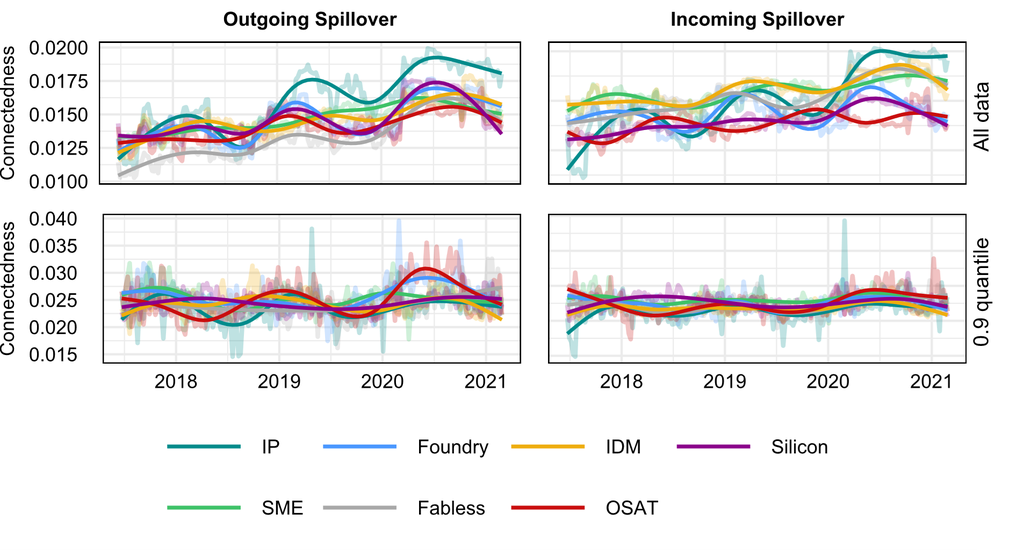

```r
e = ggarrange(a,b,c,d,ncol = 2, nrow = 2,common.legend = TRUE, legend="bottom")

ggsave(filename = "Supply Chain over time Electronics.svg",width = 16,height = 9,units = "cm",
       plot = print(e),
       device = svg)
e
```

## Individual Connectedness

Create an aggregated conntectedness matrix

```r
mat <- matrix(0, nrow = nrow(plot_info), ncol= nrow(plot_info))
for( i in 1:((nrow(Vol_data_2)-w)/5)){
  d = Con_Matrices_2[[i]][match(names2,colnames(Con_Matrices_2[[i]])),match(names2,colnames(Con_Matrices_2[[i]]))]
  d[is.na(d)] <- 0
  mat = mat + d
}

colnames(mat)<-names2
rownames(mat)<-names2

scale_m= c(rep(1/21,5),rep(1/37,6),rep(1/49,5),rep(1/42,6),rep(1/34,9),rep(1/27,7),rep(1/27,15),rep(1/53,1))

raw_eff = cbind.data.frame(names2[54],sum(mat[54,])*scale_m[54])

out_tot = cbind.data.frame(names2[1:53],rowSums(mat[1:53,1:53])*scale_m[1:53],c(plot_info[,2][1:53]),c(plot_info[,4][1:53]))
out_tot = out_tot[order(out_tot[,2],decreasing = TRUE),]
```

Calculate the total incoming and outgoing links for each firm and write it to a csv file

```r
in_tot = cbind.data.frame(names2[1:53],colSums(mat[1:53,1:53])*scale_m[1:53],c(plot_info[,2][1:53]),c(plot_info[,4][1:53]))
in_tot = in_tot[order(in_tot[,2],decreasing = TRUE),]

out_tot = cbind(out_tot, match(out_tot[,1],in_tot[,1]))
in_tot = cbind(in_tot, match(in_tot[,1],out_tot[,1]))

write.csv2(out_tot, file="Individual_Con_out Electronics.csv")
write.csv2(in_tot, file="Individual_Con_in Electronics.csv")
```

Again, only look at the top-n links

```r
mat_top <- data.frame(rep(0,length(names2)),rep(0,length(names2)))

for( i in 1:((nrow(Vol_data_2)-w)/5)){
  d = rowSums(Con_Matrices_TopN[[i]][match(names2,colnames(Con_Matrices_TopN[[i]])),match(names2,colnames(Con_Matrices_TopN[[i]]))],na.rm = T)/
      rowSums(Con_Matrices_TopN[[i]][match(names2,colnames(Con_Matrices_TopN[[i]])),match(names2,colnames(Con_Matrices_TopN[[i]]))]!=0,na.rm = T)

  e = colSums(Con_Matrices_TopN[[i]][match(names2,colnames(Con_Matrices_TopN[[i]])),match(names2,colnames(Con_Matrices_TopN[[i]]))],na.rm = T)/
      colSums(Con_Matrices_TopN[[i]][match(names2,colnames(Con_Matrices_TopN[[i]])),match(names2,colnames(Con_Matrices_TopN[[i]]))]!=0,na.rm = T)
  d[is.na(d)] <- 0
  e[is.na(e)] <- 0
  mat_top[,1] = mat_top[,1] + d
  mat_top[,2] = mat_top[,2] + e
}
colnames(mat_top)<-c("Outgoing","Incoming")
rownames(mat_top)<-names2
out_tot_N=cbind.data.frame(names2[1:53],mat_top[1:53,1],c(plot_info[,2][1:53]),c(plot_info[,4][1:53]))
out_tot_N=out_tot_N[order(out_tot_N[,2],decreasing = TRUE),]

raw_eff_N=cbind.data.frame(names2[54],mat_top[54,1])

in_tot_N=cbind.data.frame(names2[1:53],mat_top[1:53,2],c(plot_info[,2][1:53]),c(plot_info[,4][1:53]))
in_tot_N=in_tot_N[order(in_tot_N[,2],decreasing = TRUE),]

out_tot_N = cbind(out_tot_N, match(out_tot_N[,1],in_tot_N[,1]))
in_tot_N = cbind(in_tot_N, match(in_tot_N[,1],out_tot_N[,1]))

write.csv2(out_tot_N, file="Individual_out Top Quantile Electronics.csv")
write.csv2(in_tot_N, file="Individual_in Top Quantile Electronics.csv")
```

```r
top_raw <- which(mat[c("SILI"),]>=sort(mat[c("SILI"),], decreasing = T)[20], arr.ind = T)


# determine the order of the 10 largest values in decreasing order
value = cbind.data.frame(rep(names2[54],20),names2[top_raw][1:20],mat[c("SILI"),][top_raw])
value = value[order(value[,3], decreasing = T), ]
colnames(value)=c("From","To","Value")

write.csv2(value, file="Biggest Raw Material Exposure.csv")
```

Furthermore, we can determine the top 3 strongest connections between firms over time

```r
strongest_3_out=data.frame(Bigest_Out=out_tot[1:53,1], Connections=NA)
for (i in 1:53){
  strongest_3_out[i,2]=paste(names[which(mat[out_tot[i,1],]>=sort(mat[out_tot[i,1],], decreasing = T)[3], arr.ind = T)],sep="",collapse=", ")
}
strongest_3_in=data.frame(Bigest_In=in_tot[1:53,1], Connections=NA)
for (i in 1:53){
  strongest_3_in[i,2]=paste(names[which(mat[in_tot[i,1],]>=sort(mat[in_tot[i,1],], decreasing = T)[3], arr.ind = T)],sep="",collapse=", ")
}

strongest_3 = cbind(strongest_3_out,strongest_3_in)
write.csv2(strongest_3, file="Strongest Links Electronics.csv")
```

## Aggregation of connectedness matrices

On this way we can build tables showing the exposure from each region (supply chain level) to another

#### Continental Matrix

All links

```r
library(purrr)

cont=matrix(0,4,4)
cont[1,2] = sum(unlist(Cont_con %>% map(~.x[1,2])))
cont[2,1] = sum(unlist(Cont_con %>% map(~.x[2,1])))
cont[1,3] = sum(unlist(Cont_con %>% map(~.x[1,3])))
cont[3,1] = sum(unlist(Cont_con %>% map(~.x[3,1])))
cont[2,3] = sum(unlist(Cont_con %>% map(~.x[2,3])))
cont[3,2] = sum(unlist(Cont_con %>% map(~.x[3,2])))

#To others
cont[1,4]= sum(cont[1,2],cont[1,3])
cont[2,4]= sum(cont[2,1],cont[2,3])
cont[3,4]= sum(cont[3,1],cont[3,2])

#From others
cont[4,1]= sum(cont[2,1],cont[3,1])
cont[4,2]= sum(cont[1,2],cont[3,2])
cont[4,3]= sum(cont[1,3],cont[2,3])

write.csv2(cont, file="Cont_Con_Matrix Electronics.csv")
```

Top-n links

```r
cont[1,2] = sum(unlist(Cont_con_N[130:193] %>% map(~.x[1,2])))
cont[2,1] = sum(unlist(Cont_con_N[130:193] %>% map(~.x[2,1])))
cont[1,3] = sum(unlist(Cont_con_N[130:193] %>% map(~.x[1,3])))
cont[3,1] = sum(unlist(Cont_con_N[130:193] %>% map(~.x[3,1])))
cont[2,3] = sum(unlist(Cont_con_N[130:193] %>% map(~.x[2,3])))
cont[3,2] = sum(unlist(Cont_con_N[130:193] %>% map(~.x[3,2])))

#To others
cont[1,4]= sum(cont[1,2],cont[1,3])
cont[2,4]= sum(cont[2,1],cont[2,3])
cont[3,4]= sum(cont[3,1],cont[3,2])

#From others
cont[4,1]= sum(cont[2,1],cont[3,1])
cont[4,2]= sum(cont[1,2],cont[3,2])
cont[4,3]= sum(cont[1,3],cont[2,3])

write.csv2(cont, file="Cont_Con_Matrix_Top_Quantile Electronics.csv")
```

The final matrix for exposure form and to each region is crated from the written csv-file and looks as follows:

(The number in brackets shows the exposure during the COVID-period, while the number above shows the exposure over thw whole time period)

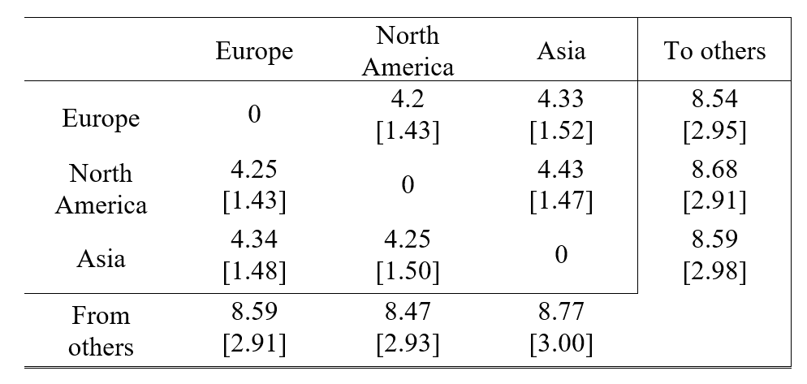

#### Supply Chain Level

All links

```r
cont=matrix(0,8,8)
cont[1,2] = sum(unlist(SC_con %>% map(~.x[1,2])))
cont[2,1] = sum(unlist(SC_con %>% map(~.x[2,1])))
cont[1,3] = sum(unlist(SC_con %>% map(~.x[1,3])))
cont[3,1] = sum(unlist(SC_con %>% map(~.x[3,1])))
cont[2,3] = sum(unlist(SC_con %>% map(~.x[2,3])))
cont[3,2] = sum(unlist(SC_con %>% map(~.x[3,2])))
cont[4,1] = sum(unlist(SC_con %>% map(~.x[4,1])))
cont[1,4] = sum(unlist(SC_con %>% map(~.x[1,4])))
cont[4,2] = sum(unlist(SC_con %>% map(~.x[4,2])))
cont[2,4] = sum(unlist(SC_con %>% map(~.x[2,4])))
cont[4,3] = sum(unlist(SC_con %>% map(~.x[3,4])))
cont[3,4] = sum(unlist(SC_con %>% map(~.x[3,4])))
cont[5,1] = sum(unlist(SC_con %>% map(~.x[5,1])))
cont[1,5] = sum(unlist(SC_con %>% map(~.x[1,5])))
cont[5,2] = sum(unlist(SC_con %>% map(~.x[5,2])))
cont[2,5] = sum(unlist(SC_con %>% map(~.x[2,5])))
cont[5,3] = sum(unlist(SC_con %>% map(~.x[5,3])))
cont[3,5] = sum(unlist(SC_con %>% map(~.x[3,5])))
cont[5,4] = sum(unlist(SC_con %>% map(~.x[5,4])))
cont[4,5] = sum(unlist(SC_con %>% map(~.x[4,5])))
cont[1,6] = sum(unlist(SC_con %>% map(~.x[1,6])))
cont[6,1] = sum(unlist(SC_con %>% map(~.x[6,1])))
cont[2,6] = sum(unlist(SC_con %>% map(~.x[2,6])))
cont[6,2] = sum(unlist(SC_con %>% map(~.x[6,2])))
cont[3,6] = sum(unlist(SC_con %>% map(~.x[3,6])))
cont[6,3] = sum(unlist(SC_con %>% map(~.x[6,3])))
cont[4,6] = sum(unlist(SC_con %>% map(~.x[4,6])))
cont[6,4] = sum(unlist(SC_con %>% map(~.x[6,4])))
cont[5,6] = sum(unlist(SC_con %>% map(~.x[5,6])))
cont[6,5] = sum(unlist(SC_con %>% map(~.x[6,5])))
cont[1,7] = sum(unlist(SC_con %>% map(~.x[1,7])))
cont[7,1] = sum(unlist(SC_con %>% map(~.x[7,1])))
cont[2,7] = sum(unlist(SC_con %>% map(~.x[2,7])))
cont[7,2] = sum(unlist(SC_con %>% map(~.x[7,2])))
cont[3,7] = sum(unlist(SC_con %>% map(~.x[3,7])))
cont[7,3] = sum(unlist(SC_con %>% map(~.x[7,3])))
cont[4,7] = sum(unlist(SC_con %>% map(~.x[4,7])))
cont[7,4] = sum(unlist(SC_con %>% map(~.x[7,4])))
cont[5,7] = sum(unlist(SC_con %>% map(~.x[5,7])))
cont[7,5] = sum(unlist(SC_con %>% map(~.x[7,5])))
cont[6,7] = sum(unlist(SC_con %>% map(~.x[6,7])))
cont[7,6] = sum(unlist(SC_con %>% map(~.x[7,6])))

#To others
cont[1,8]= sum(cont[1,2],cont[1,3],cont[1,4],cont[1,5],cont[1,6],cont[1,7])
cont[2,8]= sum(cont[2,1],cont[2,3],cont[2,4],cont[2,5],cont[2,6],cont[2,7])
cont[3,8]= sum(cont[3,1],cont[3,2],cont[3,4],cont[3,5],cont[3,6],cont[3,7])
cont[4,8]= sum(cont[4,1],cont[4,2],cont[4,3],cont[4,5],cont[4,6],cont[4,7])
cont[5,8]= sum(cont[5,1],cont[5,2],cont[5,3],cont[5,4],cont[5,6],cont[5,7])
cont[6,8]= sum(cont[6,1],cont[6,2],cont[6,3],cont[6,4],cont[6,5],cont[6,7])
cont[7,8]= sum(cont[7,1],cont[7,2],cont[7,3],cont[7,4],cont[7,5],cont[7,6])

#From others
cont[8,1]= sum(cont[2,1],cont[3,1],cont[4,1],cont[5,1],cont[6,1],cont[7,1])
cont[8,2]= sum(cont[1,2],cont[3,2],cont[4,2],cont[5,2],cont[6,2],cont[7,2])
cont[8,3]= sum(cont[1,3],cont[2,3],cont[4,3],cont[5,3],cont[6,3],cont[7,3])
cont[8,4]= sum(cont[1,4],cont[2,4],cont[3,4],cont[5,4],cont[6,4],cont[7,4])
cont[8,5]= sum(cont[1,5],cont[2,5],cont[3,5],cont[4,5],cont[6,5],cont[7,5])
cont[8,6]= sum(cont[1,6],cont[2,6],cont[3,6],cont[4,6],cont[5,6],cont[7,6])
cont[8,7]= sum(cont[1,7],cont[2,7],cont[3,7],cont[4,7],cont[5,7],cont[6,7])

write.csv2(cont, file="SC_Con_Matrix Electronics.csv")
```

Top-n links

```r
cont[1,2] = sum(unlist(SC_con_N[130:193] %>% map(~.x[1,2])))
cont[2,1] = sum(unlist(SC_con_N[130:193] %>% map(~.x[2,1])))
cont[1,3] = sum(unlist(SC_con_N[130:193] %>% map(~.x[1,3])))
cont[3,1] = sum(unlist(SC_con_N[130:193] %>% map(~.x[3,1])))
cont[2,3] = sum(unlist(SC_con_N[130:193] %>% map(~.x[2,3])))
cont[3,2] = sum(unlist(SC_con_N[130:193] %>% map(~.x[3,2])))
cont[4,1] = sum(unlist(SC_con_N[130:193] %>% map(~.x[4,1])))
cont[1,4] = sum(unlist(SC_con_N[130:193] %>% map(~.x[1,4])))
cont[4,2] = sum(unlist(SC_con_N[130:193] %>% map(~.x[4,2])))
cont[2,4] = sum(unlist(SC_con_N[130:193] %>% map(~.x[2,4])))
cont[4,3] = sum(unlist(SC_con_N[130:193] %>% map(~.x[3,4])))
cont[3,4] = sum(unlist(SC_con_N[130:193] %>% map(~.x[3,4])))
cont[5,1] = sum(unlist(SC_con_N[130:193] %>% map(~.x[5,1])))
cont[1,5] = sum(unlist(SC_con_N[130:193] %>% map(~.x[1,5])))
cont[5,2] = sum(unlist(SC_con_N[130:193] %>% map(~.x[5,2])))
cont[2,5] = sum(unlist(SC_con_N[130:193] %>% map(~.x[2,5])))
cont[5,3] = sum(unlist(SC_con_N[130:193] %>% map(~.x[5,3])))
cont[3,5] = sum(unlist(SC_con_N[130:193] %>% map(~.x[3,5])))
cont[5,4] = sum(unlist(SC_con_N[130:193] %>% map(~.x[5,4])))
cont[4,5] = sum(unlist(SC_con_N[130:193] %>% map(~.x[4,5])))
cont[1,6] = sum(unlist(SC_con_N[130:193] %>% map(~.x[1,6])))
cont[6,1] = sum(unlist(SC_con_N[130:193] %>% map(~.x[6,1])))
cont[2,6] = sum(unlist(SC_con_N[130:193] %>% map(~.x[2,6])))
cont[6,2] = sum(unlist(SC_con_N[130:193] %>% map(~.x[6,2])))
cont[3,6] = sum(unlist(SC_con_N[130:193] %>% map(~.x[3,6])))
cont[6,3] = sum(unlist(SC_con_N[130:193] %>% map(~.x[6,3])))
cont[4,6] = sum(unlist(SC_con_N[130:193] %>% map(~.x[4,6])))
cont[6,4] = sum(unlist(SC_con_N[130:193] %>% map(~.x[6,4])))
cont[5,6] = sum(unlist(SC_con_N[130:193] %>% map(~.x[5,6])))
cont[6,5] = sum(unlist(SC_con_N[130:193] %>% map(~.x[6,5])))
cont[1,7] = sum(unlist(SC_con_N[130:193] %>% map(~.x[1,7])))
cont[7,1] = sum(unlist(SC_con_N[130:193] %>% map(~.x[7,1])))
cont[2,7] = sum(unlist(SC_con_N[130:193] %>% map(~.x[2,7])))
cont[7,2] = sum(unlist(SC_con_N[130:193] %>% map(~.x[7,2])))
cont[3,7] = sum(unlist(SC_con_N[130:193] %>% map(~.x[3,7])))
cont[7,3] = sum(unlist(SC_con_N[130:193] %>% map(~.x[7,3])))
cont[4,7] = sum(unlist(SC_con_N[130:193] %>% map(~.x[4,7])))
cont[7,4] = sum(unlist(SC_con_N[130:193] %>% map(~.x[7,4])))
cont[5,7] = sum(unlist(SC_con_N[130:193] %>% map(~.x[5,7])))
cont[7,5] = sum(unlist(SC_con_N[130:193] %>% map(~.x[7,5])))
cont[6,7] = sum(unlist(SC_con_N[130:193] %>% map(~.x[6,7])))
cont[7,6] = sum(unlist(SC_con_N[130:193] %>% map(~.x[7,6])))

#To others
cont[1,8]= sum(cont[1,2],cont[1,3],cont[1,4],cont[1,5],cont[1,6],cont[1,7])/3
cont[2,8]= sum(cont[2,1],cont[2,3],cont[2,4],cont[2,5],cont[2,6],cont[2,7])/4
cont[3,8]= sum(cont[3,1],cont[3,2],cont[3,4],cont[3,5],cont[3,6],cont[3,7])/5
cont[4,8]= sum(cont[4,1],cont[4,2],cont[4,3],cont[4,5],cont[4,6],cont[4,7])/4
cont[5,8]= sum(cont[5,1],cont[5,2],cont[5,3],cont[5,4],cont[5,6],cont[5,7])/4
cont[6,8]= sum(cont[6,1],cont[6,2],cont[6,3],cont[6,4],cont[6,5],cont[6,7])/4
cont[7,8]= sum(cont[7,1],cont[7,2],cont[7,3],cont[7,4],cont[7,5],cont[7,6])/4

#From others
cont[8,1]= sum(cont[2,1],cont[3,1],cont[4,1],cont[5,1],cont[6,1],cont[7,1])/3
cont[8,2]= sum(cont[1,2],cont[3,2],cont[4,2],cont[5,2],cont[6,2],cont[7,2])/4
cont[8,3]= sum(cont[1,3],cont[2,3],cont[4,3],cont[5,3],cont[6,3],cont[7,3])/5
cont[8,4]= sum(cont[1,4],cont[2,4],cont[3,4],cont[5,4],cont[6,4],cont[7,4])/4
cont[8,5]= sum(cont[1,5],cont[2,5],cont[3,5],cont[4,5],cont[6,5],cont[7,5])/4
cont[8,6]= sum(cont[1,6],cont[2,6],cont[3,6],cont[4,6],cont[5,6],cont[7,6])/4
cont[8,7]= sum(cont[1,7],cont[2,7],cont[3,7],cont[4,7],cont[5,7],cont[6,7])/4

write.csv2(cont, file="SC_Con_Matrix_Top_Quantile Electronics.csv")
```

The final matrix for exposure form and to each supply chain level is crated from the written csv-file and looks as follows:

(The number in brackets shows the exposure during the COVID-period, while the number above shows the exposure over thw whole time period)

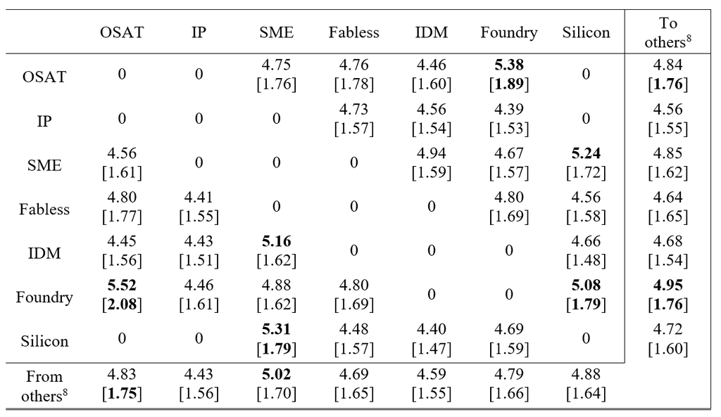

### Strongest 1% Links at a Point of time

```r
single=matrix(NA,nrow = 25*(nrow(Vol_data)-w)/5,ncol=4,dimnames = list(c(1:(25*(nrow(Vol_data)-w)/5)),c("Row","Col","From","To")))

for (i in 1:((nrow(Vol_data)-w)/5)){

  single[(1+(i-1)*25):(i*25),c(1,2)]= which(Con_Matrices_2[[i]]>=sort(Con_Matrices_2[[i]], decreasing = T)[25], arr.ind = T)

  for (j in 1:25){

    single[j+(i-1)*25,3]= colnames(Con_Matrices_2[[i]])[as.numeric(single[j+(i-1)*25,1])]
    single[j+(i-1)*25,4]= colnames(Con_Matrices_2[[i]])[as.numeric(single[j+(i-1)*25,2])]
  }}
```

Count number of firm appearances within those extreme high risk spillovers to identify the biggest risk emitters and receivers

```r
strong=as.data.frame(table(single[,3:4])[order(table(single[,3:4]),decreasing = TRUE)][1:20])
rank = cbind(as.vector(strong[,1]), as.data.frame.numeric(match(strong[,1],out_tot_N[,1])),as.data.frame.numeric(match(strong[,1],in_tot_N[,1])))
rank = cbind(rank,pmin(rank[,2], rank[,3]))
strong=cbind(strong,plot_info[match(strong[,1],names2),2],paste("(",rank[,4],".)",sep = ""))


strong_out=as.data.frame(table(single[,3])[order(table(single[,3]),decreasing = TRUE)][1:20])
rank = cbind(as.vector(strong_out[,1]), as.data.frame.numeric(match(strong_out[,1],out_tot_N[,1])))
strong_out=cbind(strong_out,plot_info[match(strong_out[,1],names2),2],paste("(",rank[,2],".)",sep = ""))

strong_in=as.data.frame(table(single[,4])[order(table(single[,4]),decreasing = TRUE)][1:20])
rank = cbind(as.vector(strong_in[,1]), as.data.frame.numeric(match(strong_in[,1],in_tot_N[,1])))
strong_in=cbind(strong_in,plot_info[match(strong_in[,1],names2),2],paste("(",rank[,2],".)",sep = ""))

colnames(strong)<-c("Name", "Absolute Frequency","Supply-Chain Level:","Ranking")
colnames(strong_out)<-c("Name", "Absolute Frequency","Supply-Chain Level:","Ranking")
colnames(strong_in)<-c("Name", "Absolute Frequency","Supply-Chain Level:","Ranking")
```

Rearrange dataframe and plot the identified firms and the number of appearances

```r
library(dplyr)
strong= strong %>%
  arrange(`Absolute Frequency`) %>%
  mutate(Name=factor(Name,levels = Name))

strong_out= strong_out %>%
  arrange(`Absolute Frequency`) %>%
  mutate(Name=factor(Name,levels = Name))

strong_in= strong_in %>%
  arrange(`Absolute Frequency`) %>%
  mutate(Name=factor(Name,levels = Name))

d=ggplot(strong_out, aes(x=Name,y=`Absolute Frequency`))+
  geom_point(aes(colour =`Supply-Chain Level:` , fill=`Supply-Chain Level:`),alpha=0.5, shape=21, stroke=2, size=1.5)+
  geom_segment( aes(x=Name, xend=Name, y=0, yend=`Absolute Frequency`,colour =`Supply-Chain Level:`), size=1)+
  theme_void()+
  xlab("\nName") + ylab("Absolute Frequency\n")+
  scale_colour_manual(breaks= c("IP","SME","Foundry","Fabless","IDM","OSAT","Sili","Raw Material Price"),values=c(`IP`="cyan4",`SME`=rgb(62,194,104,maxColorValue = 255),`Foundry`=rgb(73,151,255,maxColorValue = 255),`Fabless`=rgb(168,168,168,maxColorValue = 255),`IDM`="darkgoldenrod2",`OSAT`=rgb(201,14,14,maxColorValue = 255),`Sili`="magenta4",`Raw Material Price`="lightsteelblue"))+
  scale_fill_manual(breaks= c("IP","SME","Foundry","Fabless","IDM","OSAT","Sili","Raw Material Price"),values=c(`IP`="cyan4",`SME`=rgb(62,194,104,maxColorValue = 255),`Foundry`=rgb(73,151,255,maxColorValue = 255),`Fabless`=rgb(168,168,168,maxColorValue = 255),`IDM`="darkgoldenrod2",`OSAT`=rgb(201,14,14,maxColorValue = 255),`Sili`="magenta4",`Raw Material Price`="lightsteelblue"))+
  theme(axis.title=element_text(size=9),axis.text=element_text(size=9),legend.title = element_text( size = 9, face="bold"),legend.text = element_text( size = 9),axis.title.y=element_blank(),
        legend.position= c(0.9, 0.16), axis.title.x = element_blank(),axis.text.y = element_text(hjust = 1,margin = margin(r=0)),
        axis.text.x=element_blank(), plot.margin=margin(t=10,r=10,b=10,l=10),plot.title = element_text(hjust = 0.14))+
  geom_text(aes(label = `Absolute Frequency`), size=2.5, hjust = -0.5)+annotate(geom="text",x= c(1:20),y=-13 ,label=strong_out$Ranking,size=3)+
  coord_flip()+
  expand_limits(y = 350)+
  ggtitle("Outgoing Spillover:")

e=ggplot(strong_in, aes(x=Name,y=`Absolute Frequency`))+
  geom_point(aes(colour =`Supply-Chain Level:` , fill=`Supply-Chain Level:`),alpha=0.5, shape=21, stroke=2, size=1.5)+
  geom_segment( aes(x=Name, xend=Name, y=0, yend=`Absolute Frequency`,colour =`Supply-Chain Level:`), size=1)+
  theme_void()+
  xlab("\nName") + ylab("Absolute Frequency\n")+
  scale_colour_manual(breaks= c("IP","SME","Foundry","Fabless","IDM","OSAT","Sili","Raw Material Price"),values=c(`IP`="cyan4",`SME`=rgb(62,194,104,maxColorValue = 255),`Foundry`=rgb(73,151,255,maxColorValue = 255),`Fabless`=rgb(168,168,168,maxColorValue = 255),`IDM`="darkgoldenrod2",`OSAT`=rgb(201,14,14,maxColorValue = 255),`Sili`="magenta4",`Raw Material Price`="lightsteelblue"))+
  scale_fill_manual(breaks= c("IP","SME","Foundry","Fabless","IDM","OSAT","Sili","Raw Material Price"),values=c(`IP`="cyan4",`SME`=rgb(62,194,104,maxColorValue = 255),`Foundry`=rgb(73,151,255,maxColorValue = 255),`Fabless`=rgb(168,168,168,maxColorValue = 255),`IDM`="darkgoldenrod2",`OSAT`=rgb(201,14,14,maxColorValue = 255),`Sili`="magenta4",`Raw Material Price`="lightsteelblue"))+
  theme(axis.title=element_text(size=9),axis.text=element_text(size=9),legend.title = element_text( size = 9, face="bold"),legend.text = element_text( size = 9),axis.title.y=element_blank(),
        legend.position= c(0.9, 0.16), axis.title.x = element_blank(),axis.text.y = element_text(hjust = 1,margin = margin(r=0)),
        axis.text.x=element_blank(), plot.margin=margin(t=10,r=10,b=10,l=0),plot.title = element_text(hjust = 0.12))+
  geom_text(aes(label = `Absolute Frequency`), size=2.5, hjust = -0.5)+annotate(geom="text",x= c(1:20),y=-16 ,label=strong_in $Ranking,size=3)+
  coord_flip()+
  expand_limits(y = 400)+
  ggtitle("Incoming Spillover:")
```

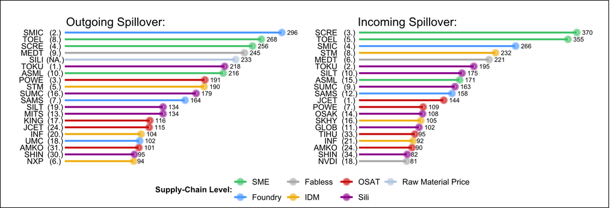

```r
f=ggarrange(d,e, ncol = 2, nrow = 1,common.legend = TRUE, legend="bottom")
f
```

```r
ggsave(filename = "lolipop Electronics Out.svg",width = 24,height = 8 ,units = "cm",
       plot = print(f),
       device = svg)

ggsave(filename = "lolipop Electronics In.svg",
       plot = print(e),
       device = svg)
```

### Individual exposure to a certain region

How much are individual companies exposed towards spillovers from a certain region?

```r
#All Region_i Comps to non-Region_i
exposure_AS=colSums(mat[grep("Asia",plot_info[match(colnames(mat),names2),4]),head(which(!grepl("Asia",plot_info[match(colnames(mat),names2),4])),-4)])/
            colSums(mat[grep("Asia",plot_info[match(colnames(mat),names2),4]),head(which(!grepl("Asia",plot_info[match(colnames(mat),names2),4])),-4)]!=0)
exposure_AS=exposure_AS[order(exposure_AS,decreasing = TRUE)]

exposure_NA=colSums(mat[grep("North America",plot_info[match(colnames(mat),names2),4]),head(which(!grepl("North America",plot_info[match(colnames(mat),names2),4])),-4)])/
            colSums(mat[grep("North America",plot_info[match(colnames(mat),names2),4]),head(which(!grepl("North America",plot_info[match(colnames(mat),names2),4])),-4)]!=0)
exposure_NA=exposure_NA[order(exposure_NA,decreasing = TRUE)]

exposure_EU=colSums(mat[grep("Europe",plot_info[match(colnames(mat),names2),4]),head(which(!grepl("Europe",plot_info[match(colnames(mat),names2),4])),-4)])/
            colSums(mat[grep("Europe",plot_info[match(colnames(mat),names2),4]),head(which(!grepl("Europe",plot_info[match(colnames(mat),names2),4])),-4)]!=0)
exposure_EU=exposure_EU[order(exposure_EU,decreasing = TRUE)]

####FOR TOP QUANTILE

exposure_AS_N=vector("list",(nrow(Vol_data_2)-w)/5)
exposure_NA_N=vector("list",(nrow(Vol_data_2)-w)/5)
exposure_EU_N=vector("list",(nrow(Vol_data_2)-w)/5)

for (i in 1:((nrow(Vol_data_2)-w)/5)){
exposure_AS_N[[i]]=colSums(Con_Matrices_TopN[[i]][grep("Asia",plot_info[match(colnames(Con_Matrices_TopN[[i]]),names2),4]),head(which(!grepl("Asia",plot_info[match(colnames(Con_Matrices_TopN[[i]]),names2),4])),-1)],na.rm = T)/
  colSums(Con_Matrices_TopN[[i]][grep("Asia",plot_info[match(colnames(Con_Matrices_TopN[[i]]),names2),4]),head(which(!grepl("Asia",plot_info[match(colnames(Con_Matrices_TopN[[i]]),names2),4])),-1)]!=0,na.rm = T)

exposure_NA_N[[i]]=colSums(Con_Matrices_TopN[[i]][grep("North America",plot_info[match(colnames(Con_Matrices_TopN[[i]]),names2),4]),head(which(!grepl("North America",plot_info[match(colnames(Con_Matrices_TopN[[i]]),names2),4])),-1)],na.rm = T)/
  colSums(Con_Matrices_TopN[[i]][grep("North America",plot_info[match(colnames(Con_Matrices_TopN[[i]]),names2),4]),head(which(!grepl("North America",plot_info[match(colnames(Con_Matrices_TopN[[i]]),names2),4])),-1)]!=0,na.rm = T)

exposure_EU_N[[i]]=colSums(Con_Matrices_TopN[[i]][grep("Europe",plot_info[match(colnames(Con_Matrices_TopN[[i]]),names2),4]),head(which(!grepl("Europe",plot_info[match(colnames(Con_Matrices_TopN[[i]]),names2),4])),-1)],na.rm = T)/
  colSums(Con_Matrices_TopN[[i]][grep("Europe",plot_info[match(colnames(Con_Matrices_TopN[[i]]),names2),4]),head(which(!grepl("Europe",plot_info[match(colnames(Con_Matrices_TopN[[i]]),names2),4])),-1)]!=0,na.rm = T)

exposure_AS_N[[i]][which(is.nan(exposure_AS_N[[i]]))]<-0
exposure_NA_N[[i]][which(is.nan(exposure_NA_N[[i]]))]<-0
exposure_EU_N[[i]][which(is.nan(exposure_EU_N[[i]]))]<-0

exposure_AS_N[[i]]=as.data.frame(exposure_AS_N[[i]])
exposure_NA_N[[i]]=as.data.frame(exposure_NA_N[[i]])
exposure_EU_N[[i]]=as.data.frame(exposure_EU_N[[i]])
}

exposure_AS_top=data.frame(rep(0,length(head(plot_info[plot_info[,4]!="Asia",1],-1))),row.names = head(plot_info[plot_info[,4]!="Asia",1],-1))
d=exposure_AS_top
for (i in 1:((nrow(Vol_data_2)-w)/5)){
d[match(rownames(exposure_AS_N[[i]]),rownames(exposure_AS_top)),1] = exposure_AS_N[[i]]
exposure_AS_top = exposure_AS_top + d
d[,]<-0
}

exposure_NA_top=data.frame(rep(0,length(head(plot_info[plot_info[,4]!="North America",1],-1))),row.names = head(plot_info[plot_info[,4]!="North America",1],-1))
d=exposure_NA_top
for (i in 1:((nrow(Vol_data_2)-w)/5)){
  d[match(rownames(exposure_NA_N[[i]]),rownames(exposure_NA_top)),1] = exposure_NA_N[[i]]
  exposure_NA_top = exposure_NA_top + d
  d[,]<-0
}


exposure_EU_top=data.frame(rep(0,length(head(plot_info[plot_info[,4]!="Europe",1],-1))),row.names = head(plot_info[plot_info[,4]!="Europe",1],-1))
d=exposure_EU_top
for (i in 1:((nrow(Vol_data_2)-w)/5)){
  d[match(rownames(exposure_EU_N[[i]]),rownames(exposure_EU_top)),1] = exposure_EU_N[[i]]
  exposure_EU_top = exposure_EU_top + d
  d[,]<-0
}

exposure_AS_top[,2]=rownames(exposure_AS_top)
exposure_AS_top=exposure_AS_top[,c(2,1)]

exposure_AS_top=exposure_AS_top[order(exposure_AS_top[,2],decreasing = TRUE),,drop=F]
exposure_NA_top=exposure_NA_top[order(exposure_NA_top[,1],decreasing = TRUE),,drop=F]
exposure_EU_top=exposure_EU_top[order(exposure_EU_top[,1],decreasing = TRUE),,drop=F]
```

```r
biggest_exposure= cbind.data.frame(1:15,rownames(as.data.frame(exposure_AS[1:15])),exposure_AS[1:15],rownames(exposure_AS_top)[1:15],exposure_AS_top[1:15,2],
                                   rownames(as.data.frame(exposure_NA[1:15])),exposure_NA[1:15],rownames(exposure_NA_top)[1:15],exposure_NA_top[1:15,1],
                                   rownames(as.data.frame(exposure_EU[1:15])),exposure_EU[1:15],rownames(exposure_EU_top)[1:15],exposure_EU_top[1:15,1])
colnames(biggest_exposure)<-c("Rank","From Asia","All","From Asia","Quantile","From North America","All","From North America","Quantile",
                              "Frome Europe","All","Frome Europe","Quantile")

write.csv2(biggest_exposure, file="Exposure ind. towards region.csv")
```

The final table of individual firm exposures towards a certain region is created from the csv-file and looks as follows:

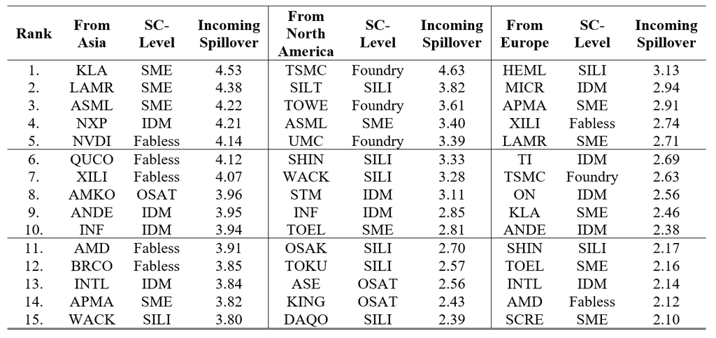